# Analysis ~ Replication study of Kerwer et al.(2020)

LCP lab

2022-05-29

## 匯入及預覽資料欄位資訊

```r
## locate the rawdata file
zip_path <- list.files(path = "..",pattern = "jatos_results.zip",include.dirs = TRUE,recursive = TRUE,full.names = TRUE)
## import raw data
df <- read_csv(unz(zip_path, filename = "rawdata.csv"))
## import text id table; script did not log text_id
text <- read_csv("../4_OS_Result/text_id.csv")
## Append text id to rawdata df
```

整合有效參與者的原始回應資料檔“rawdata.csv”，存放路徑是../4_OS_Result/jatos_results.zip。資料欄位共有57項，來自150位參與者，41850筆回應資料。

資料編碼薄以codebook套件製作，製作完成存放路徑與本文件相同。

```r
## Extract the system variables
df_sys <- df %>% dplyr::select(starts_with(c("identifier","jatos","browser_","count_","date_","experiment_","screen_","system_","Start ","Last ","Duration","Batch","Worker ","State","Message")))

## Reserve the analytic variables in rawdata df
df <- df %>% dplyr::select(!names(df_sys)[-c(1,2)])

## Split basic data
df_Basic <- filter(df, Q_type == "Basic")
## Exclude the variables full of "None"
df_Basic <- df_Basic[,(colSums(df_Basic!="None",na.rm = TRUE) != 0 ) # Get "response"
]

## Split Belief data
df_Belief <- filter(df, Q_type == "Belief")
## Exclude the variables full of "None"
df_Belief <- df_Belief[,which(colSums(df_Belief!="None",na.rm = TRUE) != 0 )]

## Split self evaluation data
df_self_eval <- filter(df, Q_type == "self_eval")
## Exclude the variables full of "None"
df_self_eval <- df_self_eval[,which(colSums(df_self_eval!="None",na.rm = TRUE) != 0)]

## Split post reading Question data
df_Post <- dplyr::filter(df, Q_type == "Post_survey") %>% left_join(text, by= "Content")
## Exclude the variables full of "None"
df_Post <- df_Post[,which(colSums(df_Post!="None",na.rm = TRUE) != 0)] %>% mutate(Text_id = as.character(Text_id))

## Split knowledge data
df_knowledge <- filter(df, Q_type == "Knowledge" & Q_presented == 1) ## Reserved presented questions
## Exclude the variables full of "None"
df_knowledge <- left_join(dplyr::select(df_knowledge[,which(colSums(df_knowledge!="None",na.rm = TRUE) != 0)], -c("NH","OSA","text_order")), ## Erase IV variables because they are meaningless in test loop
  dplyr::select(df_Post, jatosStudyResultId, NH, OSA, Text_id, text_order) %>% distinct(),## Extract IV variables from df_Post
by=c("jatosStudyResultId","Test_id"="Text_id")) ## Add IV vriables to df_knowledge by Test_id

## Split Exit
df_Exit <- filter(df, Q_type == "Exit")
## Exclude the variables full of "None"
df_Exit <- df_Exit[,which(colSums(df_Exit!="None",na.rm = TRUE) != 0)]
```

## 參與者基本資訊統計

- 作答時間分佈

```r
## Convert duration to minutes
minutes_count <- ((df_sys$Duration %>% hms() %>% hour()*60)+
(df_sys$Duration %>% hms() %>% minute()))

## Summary of study duration by minutes
minutes_count %>% summary()
```

```
##    Min. 1st Qu.  Median    Mean 3rd Qu.    Max.
##   24.00   33.00   39.00   59.01   49.00  941.00
```

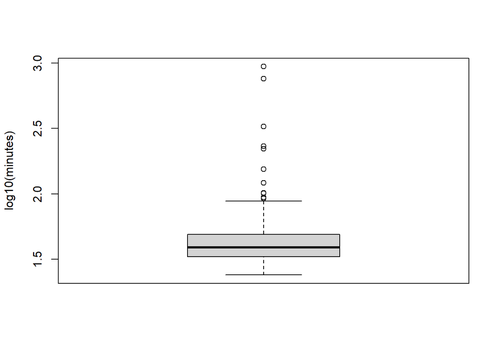

```r
## draw a box plot
minutes_count%>%
  log10() %>% ## convert minutes to log10
  boxplot(ylab="log10(minutes)")
```

### 作答時間與理解正確率散佈趨勢

```r
## Convert duration to minutes
df_post_trend  <- (df_sys %>% distinct() %>%
  dplyr::select(jatosStudyResultId, Duration) %>%
  mutate(minutes_count =
                    (Duration %>% hms() %>% hour())*60 +
                    Duration %>% hms() %>% minute() )) %>%
  left_join( (df_knowledge %>%
#  filter(Q_presented == 1) %>%   ## 過濾未出現的題目
  mutate(response = ifelse(response == "是","y","n")) %>%       #轉換參與者回答"是"換成"y"
  mutate(score = ifelse(response == correct_response,1,0)) %>%  #檢測如果回答等於正確答案得1分
  group_by(jatosStudyResultId) %>%                               #以個人分組
  summarise(Correct_rate = mean(score))),    #計算正確率
by="jatosStudyResultId")

Correct_rate <- df_post_trend %>%
  summarise(CR = mean(Correct_rate)) %>%
  print()
```

```
## # A tibble: 1 x 1
##      CR
##   <dbl>
## 1 0.710
```

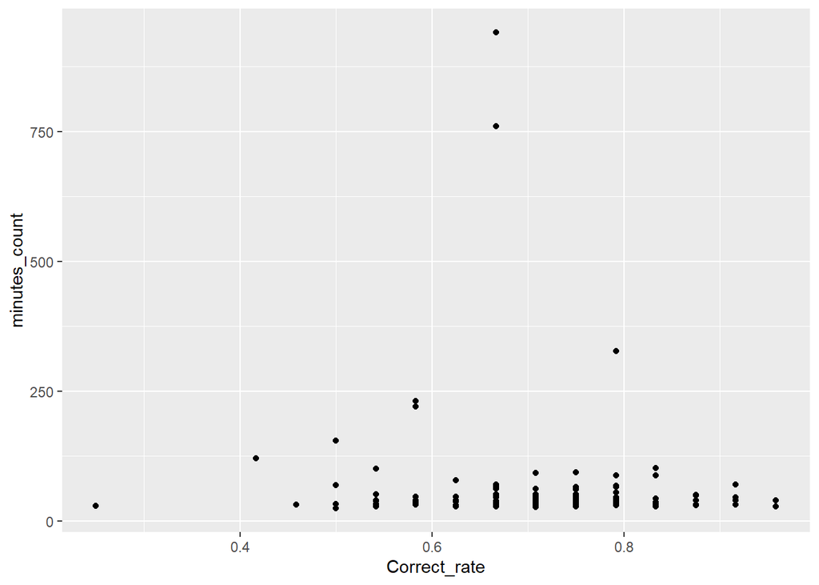

```r
ggplot(df_post_trend,aes(x=Correct_rate, y=minutes_count))+
   geom_point()
```

以下程式碼挑出極端參與者

```r
strange_id <- df_post_trend %>%
  filter(!(Correct_rate >0.5) | minutes_count > 200 ) %>%
  pull(jatosStudyResultId)
```

共有12參與者理解題正確率未超過50%或作答時間超過200分鐘。排除後，採用138 參與者資料進行以下資料處理及統計分析。

**參與者性別人數**

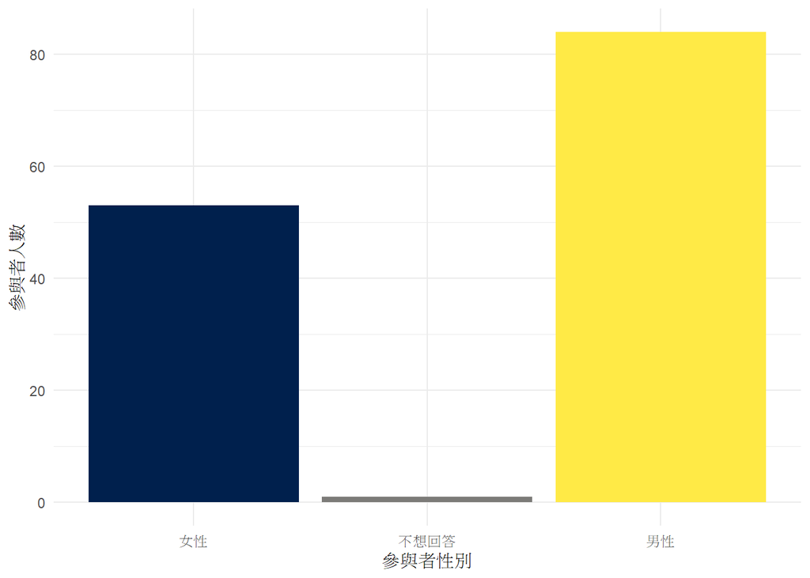

```r
df_Basic %>% filter(Topic=="gender" & !(jatosStudyResultId %in% strange_id)) %>%
  ggplot(aes(x = response, fill = response)) +
  geom_bar(show.legend = FALSE) +
  scale_x_discrete(name = "參與者性別") +
  scale_y_continuous(name = "參與者人數") +
  theme_minimal() +
  scale_fill_viridis_d(option = "E")
```

**參與者年齡分佈**

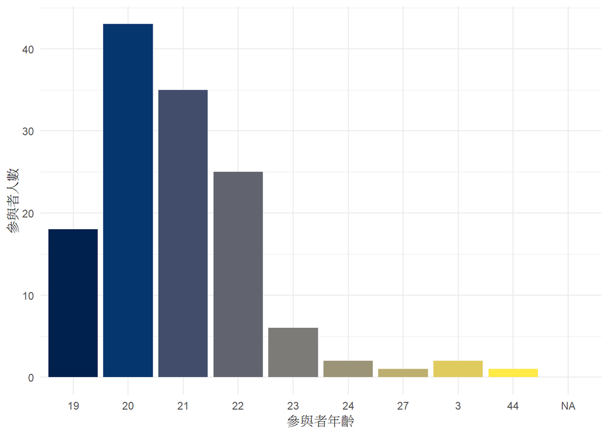

```r
## Confirm the median and MAD
response_b <- df_Basic %>% filter(Topic=="birth" & !(jatosStudyResultId %in% strange_id)) %>%
  summarise(M = median(as.numeric(response),na.rm = TRUE),
            dev= mad(as.numeric(response),na.rm = TRUE),
            min(as.numeric(response),na.rm = TRUE),
            max(as.numeric(response),na.rm = TRUE))
## median = 2, MAD = 1.48; median +/- 66 MAD are acceptable responses.
df_Basic %>% filter(Topic=="birth" & !(jatosStudyResultId %in% strange_id)) %>%
  mutate(last_two = ifelse(as.numeric(response)< response_b$M + 66*response_b$dev,as.numeric(response),NA), ## Turn strange response to missing value NA
         age = ifelse(!is.na(last_two),ifelse(last_two>50,2022-(1900+last_two),2022-(2000+last_two) ),NA )) %>% ## Estimate participant's age
#df_Basic %>% filter(Topic=="birth") %>%
  ggplot(aes(x = as.character(age), fill = as.character(age))) +
  geom_bar(show.legend = FALSE) +
  scale_x_discrete(name = "參與者年齡") +
  scale_y_continuous(name = "參與者人數") +
  theme_minimal() +
  scale_fill_viridis_d(option = "E")
```

## 問卷反應項目描述統計

> 依問題型態摘要
- 知識信念(belief) (采妤)

```r
df_Belief$response <- sapply(
 strsplit(
 gsub(df_Belief$response,pattern = " ",replacement = ""),
 split = "："
 ),
 "[[",
 1
 )

tb_Belief <- df_Belief %>% #filter(response %>%
#  summarise("6：完全正確" = mean(rating == 6),
#"5：大部份正確" = mean(rating == 5),
#"4：有點正確" = mean(rating == 4),
#"3：不太可能是正確的" = mean(rating == 3),
#"2：大部份不正確" = mean(rating == 2),
#"1：完全不正確" = mean(rating == 1))) %>%
filter(!(jatosStudyResultId %in% strange_id)) %>%
  group_by(jatosStudyResultId, Q_type,Topic) %>%
         summarise(score = mean(as.numeric(response),na.rm = TRUE)) %>% ## 參與者分項評分總計
        group_by(Q_type,Topic) %>%
         summarise(N = n(),
                   M = mean(score),
                   SD = sd(score)) ## 表列評分總計
#  ggplot(df_Belief, aes(Question, response, fill=Q)) +
#  stat_summary(fun = mean, geom = "col", alpha = 0.5) +
#  stat_summary(fun.data = mean_se, geom = "errorbar",
#               width = 0.25) +
#  coord_cartesian(ylim = c(1, 5))
```

| Q_type | Topic | N | M | SD |
| --- | --- | --- | --- | --- |
| Belief | JA | 138 | 3.615942 | 0.8504588 |
| Belief | MS | 138 | 5.137681 | 0.6528101 |
| Belief | PJ | 138 | 3.219807 | 0.8090089 |

- 科學活動經驗(self eval) (明翰)

```r
df_self_eval$response <- sapply(
 strsplit(
 gsub(df_self_eval$response,pattern = " ",replacement = ""),
 split = ":"
 ),
 "[[",
 1
 )

dm_self_eval <- df_self_eval %>%#$response <- #filter(.data = df_self_eval, Topic %in% c("ability","familiarity")) %>%
filter(!(jatosStudyResultId %in% strange_id)) %>%
  mutate(response=as.numeric(response))

# 因為每個題目都有出現過至少一次，所有題目皆有過參與者填答，故不需要過濾。
# 以摘要分組
dm_self_eval %>%
group_by(Topic) %>%
summarise(N = n(), M = mean(as.numeric(response),na.rm=TRUE ), SD = sd(as.numeric(response),na.rm=TRUE ), Missing = sum(is.na(response)))#sum(score)/n() #計算正確率
```

```
## # A tibble: 2 x 5
##   Topic           N     M    SD Missing
##   <chr>       <int> <dbl> <dbl>   <int>
## 1 ability       138  4.25  1.33       0
## 2 familiarity   138  3.37  2.14       0
```

- 讀後調查(Post Survey) (祥偉)

```r
df_Post$response <- sapply(
 strsplit(
 gsub(df_Post$response,pattern = " ",replacement = ""),
 split = ":"
 ),
 "[[",
 1
 )

## Change full access response to numeric
df_Post$response = ifelse(df_Post$response == "想", 1, ifelse(df_Post$response == "不想",0,df_Post$response))

## convert df_Post responses to numeric
df_Post$response = as.numeric(df_Post$response)

#new_post <- filter(.data = df_Post,Topic %in% c("Comprehensibility","Scientificness","Credibility","Veracity","Decision") & !(jatosStudyResultId %in% strange_id)) %>%
##抓出要分析的TOPIC

#mutate(summary = ifelse(NH == "N" & OSA == "Y", "OSA",ifelse(NH == "N" & OSA == "N", "PLS","NH_PLS")))
#將摘要分類為PLS、OSA、NH_PLS
#new_post$response <- gsub("8: 完全讀得懂", 8, new_post$response)
#new_post$response <- gsub("8: 非常有科學性", 8, new_post$response)
#new_post$response <- gsub("8: 非常可信", 8, new_post$response)
#new_post$response <- gsub("8: 我認為一定可以", 8, new_post$response)
#new_post$response <- gsub("1: 完全不可信", 1, new_post$response)
#new_post$response <- gsub("1: 完全沒有科學性", 1, new_post$response)
#new_post$response <- gsub("1: 完全讀不懂", 1, new_post$response)
#new_post$response <- gsub("1: 我認為完全不可以", 1, new_post$response)
##將包含中文的response替換數字
tb_Post <- (dm_Post <- df_Post %>% filter(Topic %in% c("Comprehensibility","Scientificness","Credibility","Veracity","Decision","Access") & !(jatosStudyResultId %in% strange_id)) %>%
mutate(article_type = ifelse(NH == "N" & OSA == "Y", "OSA",ifelse(NH == "N" & OSA == "N", "PLS","PLS_NH"))) ) %>%
#table3_cells <- new_post %>%
#        filter(summary == "PLS")   %>%
        group_by(jatosStudyResultId,Topic,article_type) %>%
        summarise(post_score = mean(as.numeric(response),na.rm = TRUE)) %>% ## 參與者分項評分總計
  group_by(Topic, article_type) %>%
         summarise(N = n(),
                   M = mean(post_score,na.rm = TRUE),
                   SD = sd(post_score,na.rm = TRUE)
)
```

| Topic | article_type | N | M | SD |
| --- | --- | --- | --- | --- |
| Access | OSA | 138 | 0.3478261 | 0.3861597 |
| Access | PLS | 138 | 0.4021739 | 0.3873393 |
| Access | PLS_NH | 138 | 0.3605072 | 0.3903701 |
| Comprehensibility | OSA | 138 | 5.3931159 | 1.0099359 |
| Comprehensibility | PLS | 138 | 6.5760870 | 0.8460992 |
| Comprehensibility | PLS_NH | 138 | 6.0960145 | 0.9643852 |
| Credibility | OSA | 138 | 5.1811594 | 1.0562501 |
| Credibility | PLS | 138 | 5.4981884 | 0.9405195 |
| Credibility | PLS_NH | 138 | 5.4402174 | 0.9477953 |
| Decision | OSA | 138 | 3.7083333 | 1.2785368 |
| Decision | PLS | 138 | 4.4202899 | 1.4164652 |
| Decision | PLS_NH | 138 | 4.2282609 | 1.3123078 |
| Scientificness | OSA | 138 | 5.2445652 | 0.9710534 |
| Scientificness | PLS | 138 | 5.5452899 | 0.9148189 |
| Scientificness | PLS_NH | 138 | 5.3442029 | 0.8966701 |
| Veracity | OSA | 138 | 4.6413043 | 1.1569200 |
| Veracity | PLS | 138 | 5.1431159 | 1.1240924 |
| Veracity | PLS_NH | 138 | 5.0000000 | 1.1514035 |

- 閱讀理解(Knowledge) (子渝)

```r
## 參與者分項評分總計
P_accuracy <- (dm_knowledge <- df_knowledge %>%
  filter(!(jatosStudyResultId %in% strange_id)) %>%   ## 過濾極端參與者
  mutate(article_type = ifelse(NH == "N" & OSA == "Y", "OSA",ifelse(NH == "N" & OSA == "N", "PLS","PLS_NH"))) %>%                                                             #將摘要分類為PLS、OSA、NH_PLS
  mutate(response = ifelse(response == "是","y","n")) %>%       #轉換參與者回答"是"換成"y"
  mutate(score = ifelse(response == correct_response,1,0)) ) %>%    #檢測如果回答等於正確答案得1分
  group_by(jatosStudyResultId, article_type) %>% #以個別參與者及摘要分組
  summarise(p_accuracy = sum(score)/length(score)
              ) #%>%

## 分項評分總計
tb_knowledge1 <- P_accuracy %>%
  group_by(article_type) %>%                                         #以摘要分組
  summarise(N = n(), M = mean(p_accuracy,na.rm=TRUE), SD = sd(p_accuracy,na.rm=TRUE)#sum(score)/n()
              )                      #計算正確率
## Retrieve the participants had all types of questions
#full_id <- P_accuracy %>% count(jatosStudyResultId) %>%
#  filter(n==3) %>% pull(jatosStudyResultId)
#tb_knowledge2 <- P_accuracy %>%
#  filter(jatosStudyResultId %in% full_id) %>%
#  group_by(article_type) %>%                                         #以摘要分組
#  summarise(N = n(), M = mean(p_accuracy,na.rm=TRUE), SD = sd(p_accuracy,na.rm=TRUE)#sum(score)/n()
#             )                      #計算正確率

## 資料整理
knowledge <- df_knowledge %>%
  filter(!(jatosStudyResultId %in% strange_id)) %>%   ## 過濾未出現的題目
  mutate(summary = ifelse(NH == "N" & OSA == "Y", "OSA",ifelse(NH == "N" & OSA == "N", "PLS","NH_PLS"))) %>%                                                             #將摘要分類為PLS、OSA、NH_PLS
  mutate(response = ifelse(response == "是","y","n")) %>%       #轉換參與者回答"是"換成"y"
  mutate(score = ifelse(response == correct_response,1,0))      #檢測如果回答等於正確答案得1分
## 總正確數
table(knowledge$score)
```

```
##
##    0    1
##  911 2401
```

```r
## 總正確率
table(knowledge$score)/sum(table(knowledge$score))
```

```
##
##         0         1
## 0.2750604 0.7249396
```

```r
## 各類摘要錯誤率
table(knowledge$score, knowledge$summary)[1,]/colSums(table(knowledge$score, knowledge$summary))
```

```
##    NH_PLS       OSA       PLS
## 0.2590580 0.2925725 0.2735507
```

```r
print("各類摘要正確率")
```

```
## [1] "各類摘要正確率"
```

```r
table(knowledge$score, knowledge$summary)[2,]/colSums(table(knowledge$score, knowledge$summary))
```

```
##    NH_PLS       OSA       PLS
## 0.7409420 0.7074275 0.7264493
```

三種文本閱讀正確率平均值及標準差

納入所有非極端值的參與者

| article_type | N | M | SD |
| --- | --- | --- | --- |
| OSA | 138 | 0.7074275 | 0.1623114 |
| PLS | 138 | 0.7264493 | 0.1580783 |
| PLS_NH | 138 | 0.7409420 | 0.1469254 |

- 出口回饋(Exit)

## 確證性分析

### 1. 可理解程度評估

對於摘要的理解

- 主觀評分

```r
# Confirmatory Analyses

## H1 Comprehensibility

## 轉換獨變項
df_Post <- df_Post %>%
mutate(article_type = ifelse(NH == "N" & OSA == "Y", "OSA",ifelse(NH == "N" & OSA == "N", "PLS","PLS_NH")))


## 計算參與者單位及文章單位的組內相關程度ICC

# conduct icc

m0 <- lmer(response ~ (1 | jatosStudyResultId), data = subset(df_Post, Topic == "Comprehensibility") )

summary(m0)
```

```
## Linear mixed model fit by REML. t-tests use Satterthwaite's method [
## lmerModLmerTest]
## Formula: response ~ (1 | jatosStudyResultId)
##    Data: subset(df_Post, Topic == "Comprehensibility")
##
## REML criterion at convergence: 6598
##
## Scaled residuals:
##     Min      1Q  Median      3Q     Max
## -3.9737 -0.4766  0.1345  0.6586  2.0158
##
## Random effects:
##  Groups             Name        Variance Std.Dev.
##  jatosStudyResultId (Intercept) 0.4966   0.7047
##  Residual                       2.0388   1.4279
## Number of obs: 1800, groups:  jatosStudyResultId, 150
##
## Fixed effects:
##              Estimate Std. Error        df t value Pr(>|t|)
## (Intercept)   5.96444    0.06666 148.99999   89.48   <2e-16 ***
## ---
## Signif. codes:  0 '***' 0.001 '**' 0.01 '*' 0.05 '.' 0.1 ' ' 1
```

```r
performance::icc(m0)
```

```
## # Intraclass Correlation Coefficient
##
##      Adjusted ICC: 0.196
##   Conditional ICC: 0.196
```

```r
H1_participant_icc <- (performance::icc(m0) %>% unlist())[1]

m00 <- lmer(response ~ (1 | Test_id), data = subset(df_Post, Topic == "Comprehensibility"))

summary(m00)
```

```
## Linear mixed model fit by REML. t-tests use Satterthwaite's method [
## lmerModLmerTest]
## Formula: response ~ (1 | Test_id)
##    Data: subset(df_Post, Topic == "Comprehensibility")
##
## REML criterion at convergence: 6776.9
##
## Scaled residuals:
##     Min      1Q  Median      3Q     Max
## -3.2126 -0.5772  0.0548  0.6867  1.4516
##
## Random effects:
##  Groups   Name        Variance Std.Dev.
##  Test_id  (Intercept) 0.03727  0.1931
##  Residual             2.50419  1.5825
## Number of obs: 1800, groups:  Test_id, 13
##
## Fixed effects:
##             Estimate Std. Error       df t value Pr(>|t|)
## (Intercept)  5.97302    0.06681 10.44563    89.4   <2e-16 ***
## ---
## Signif. codes:  0 '***' 0.001 '**' 0.01 '*' 0.05 '.' 0.1 ' ' 1
```

```r
performance::icc(m00)
```

```
## # Intraclass Correlation Coefficient
##
##      Adjusted ICC: 0.015
##   Conditional ICC: 0.015
```

```r
H1_study_icc <- (performance::icc(m00) %>% unlist())[1]

## mixed-effect models
## 確認最適模型

m1 <- lmer(response ~ (1 | jatosStudyResultId) + article_type + (1 | Text_id), data = subset(df_Post, Topic == "Comprehensibility"))

anova(m0,m1) ## fittest is m1
```

```
## Data: subset(df_Post, Topic == "Comprehensibility")
## Models:
## m0: response ~ (1 | jatosStudyResultId)
## m1: response ~ (1 | jatosStudyResultId) + article_type + (1 | Text_id)
##    npar    AIC    BIC  logLik deviance  Chisq Df Pr(>Chisq)
## m0    3 6600.4 6616.9 -3297.2   6594.4
## m1    6 6238.2 6271.1 -3113.1   6226.2 368.28  3  < 2.2e-16 ***
## ---
## Signif. codes:  0 '***' 0.001 '**' 0.01 '*' 0.05 '.' 0.1 ' ' 1
```

```r
summary(m1)
```

```
## Linear mixed model fit by REML. t-tests use Satterthwaite's method [
## lmerModLmerTest]
## Formula: response ~ (1 | jatosStudyResultId) + article_type + (1 | Text_id)
##    Data: subset(df_Post, Topic == "Comprehensibility")
##
## REML criterion at convergence: 6235.4
##
## Scaled residuals:
##     Min      1Q  Median      3Q     Max
## -4.3343 -0.5224  0.0922  0.6816  2.8226
##
## Random effects:
##  Groups             Name        Variance Std.Dev.
##  jatosStudyResultId (Intercept) 0.5331   0.7302
##  Text_id            (Intercept) 0.1809   0.4253
##  Residual                       1.6004   1.2651
## Number of obs: 1800, groups:  jatosStudyResultId, 150; Text_id, 12
##
## Fixed effects:
##                     Estimate Std. Error        df t value Pr(>|t|)
## (Intercept)        5.336e+00  1.459e-01 1.947e+01  36.562   <2e-16 ***
## article_typePLS    1.180e+00  7.313e-02 1.637e+03  16.133   <2e-16 ***
## article_typePLS_NH 7.047e-01  7.313e-02 1.637e+03   9.636   <2e-16 ***
## ---
## Signif. codes:  0 '***' 0.001 '**' 0.01 '*' 0.05 '.' 0.1 ' ' 1
##
## Correlation of Fixed Effects:
##             (Intr) ar_PLS
## artcl_tyPLS -0.251
## artc_PLS_NH -0.251  0.500
```

```r
## Tukey test
## 文章型態多重比較

test = glht(m1,linfct=mcp(article_type="Tukey"))
summary(test, test = adjusted("none"))
```

```
##
##   Simultaneous Tests for General Linear Hypotheses
##
## Multiple Comparisons of Means: Tukey Contrasts
##
##
## Fit: lmer(formula = response ~ (1 | jatosStudyResultId) + article_type +
##     (1 | Text_id), data = subset(df_Post, Topic == "Comprehensibility"))
##
## Linear Hypotheses:
##                   Estimate Std. Error z value Pr(>|z|)
## PLS - OSA == 0     1.17975    0.07313  16.133  < 2e-16 ***
## PLS_NH - OSA == 0  0.70467    0.07313   9.636  < 2e-16 ***
## PLS_NH - PLS == 0 -0.47508    0.07313  -6.497  8.2e-11 ***
## ---
## Signif. codes:  0 '***' 0.001 '**' 0.01 '*' 0.05 '.' 0.1 ' ' 1
## (Adjusted p values reported -- none method)
```

### 2. 知識獲取度評估

理解測驗正確率

```r
# Confirmatory Analyses

## H2 Knowledge Test
## 轉換獨變項, 依變項數值

df_knowledge <- df_knowledge %>%
  filter(!(jatosStudyResultId %in% strange_id)) %>%   ## 過濾極端參與者
  mutate(article_type = ifelse(NH == "N" & OSA == "Y", "OSA",ifelse(NH == "N" & OSA == "N", "PLS","PLS_NH"))) %>%                                                             #將摘要分類為PLS、OSA、NH_PLS
  mutate(response = ifelse(response == "是","y","n")) %>%       #轉換參與者回答"是"換成"y"
  mutate(score = ifelse(response == correct_response,1,0))

# mixed-effect models
## 確認最適模型
m0 <- glmer(score ~ (1 | jatosStudyResultId), family = binomial("logit"), data = df_knowledge)

m00 <- glmer(score ~ (1 | Test_id), family = binomial("logit"), data = df_knowledge)


m1 <- glmer(score ~ (1 | jatosStudyResultId) + article_type + (1 | Test_id), family = binomial("logit"), data = df_knowledge)

anova(m0,m1) ## fittest is m1
```

```
## Data: df_knowledge
## Models:
## m0: score ~ (1 | jatosStudyResultId)
## m1: score ~ (1 | jatosStudyResultId) + article_type + (1 | Test_id)
##    npar    AIC    BIC  logLik deviance  Chisq Df Pr(>Chisq)
## m0    2 3900.0 3912.2 -1948.0   3896.0
## m1    5 3759.1 3789.7 -1874.6   3749.1 146.83  3  < 2.2e-16 ***
## ---
## Signif. codes:  0 '***' 0.001 '**' 0.01 '*' 0.05 '.' 0.1 ' ' 1
```

```r
summary(m1)
```

```
## Generalized linear mixed model fit by maximum likelihood (Laplace
##   Approximation) [glmerMod]
##  Family: binomial  ( logit )
## Formula: score ~ (1 | jatosStudyResultId) + article_type + (1 | Test_id)
##    Data: df_knowledge
##
##      AIC      BIC   logLik deviance df.resid
##   3759.1   3789.7  -1874.6   3749.1     3307
##
## Scaled residuals:
##     Min      1Q  Median      3Q     Max
## -3.7901 -1.2324  0.5391  0.6655  0.9019
##
## Random effects:
##  Groups             Name        Variance Std.Dev.
##  jatosStudyResultId (Intercept) 0.03229  0.1797
##  Test_id            (Intercept) 0.39385  0.6276
## Number of obs: 3312, groups:  jatosStudyResultId, 138; Test_id, 12
##
## Fixed effects:
##                    Estimate Std. Error z value Pr(>|z|)
## (Intercept)         0.96008    0.19481   4.928  8.3e-07 ***
## article_typePLS     0.12509    0.09742   1.284   0.1991
## article_typePLS_NH  0.18998    0.09822   1.934   0.0531 .
## ---
## Signif. codes:  0 '***' 0.001 '**' 0.01 '*' 0.05 '.' 0.1 ' ' 1
##
## Correlation of Fixed Effects:
##             (Intr) ar_PLS
## artcl_tyPLS -0.243
## artc_PLS_NH -0.242  0.488
```

```r
## Tukey test
## 文章型態多重比較

test = glht(m1,linfct=mcp(article_type="Tukey"))
summary(test, test = adjusted("none"))
```

```
##
##   Simultaneous Tests for General Linear Hypotheses
##
## Multiple Comparisons of Means: Tukey Contrasts
##
##
## Fit: glmer(formula = score ~ (1 | jatosStudyResultId) + article_type +
##     (1 | Test_id), data = df_knowledge, family = binomial("logit"))
##
## Linear Hypotheses:
##                   Estimate Std. Error z value Pr(>|z|)
## PLS - OSA == 0     0.12509    0.09742   1.284   0.1991
## PLS_NH - OSA == 0  0.18998    0.09822   1.934   0.0531 .
## PLS_NH - PLS == 0  0.06489    0.09900   0.655   0.5122
## ---
## Signif. codes:  0 '***' 0.001 '**' 0.01 '*' 0.05 '.' 0.1 ' ' 1
## (Adjusted p values reported -- none method)
```

### 3. 來源可信度評估

對摘要來源的可信度

```r
# Confirmatory Analyses

## H3 Credibility

## 計算參與者單位及文章單位的組內相關程度ICC

m0 <- lmer(response ~ (1 | jatosStudyResultId), data = subset(df_Post, Topic == "Credibility"))
m00 <- lmer(response ~ (1 | Test_id), data = subset(df_Post, Topic == "Credibility"))

summary(m0)
```

```
## Linear mixed model fit by REML. t-tests use Satterthwaite's method [
## lmerModLmerTest]
## Formula: response ~ (1 | jatosStudyResultId)
##    Data: subset(df_Post, Topic == "Credibility")
##
## REML criterion at convergence: 5708.4
##
## Scaled residuals:
##     Min      1Q  Median      3Q     Max
## -4.2044 -0.5564  0.0304  0.6172  2.8694
##
## Random effects:
##  Groups             Name        Variance Std.Dev.
##  jatosStudyResultId (Intercept) 0.6876   0.8292
##  Residual                       1.1716   1.0824
## Number of obs: 1800, groups:  jatosStudyResultId, 150
##
## Fixed effects:
##              Estimate Std. Error        df t value Pr(>|t|)
## (Intercept)   5.32222    0.07235 149.00000   73.56   <2e-16 ***
## ---
## Signif. codes:  0 '***' 0.001 '**' 0.01 '*' 0.05 '.' 0.1 ' ' 1
```

```r
performance::icc(m0)
```

```
## # Intraclass Correlation Coefficient
##
##      Adjusted ICC: 0.370
##   Conditional ICC: 0.370
```

```r
H3_participant_icc <- (performance::icc(m0) %>% unlist())[1]

summary(m00)
```

```
## Linear mixed model fit by REML. t-tests use Satterthwaite's method [
## lmerModLmerTest]
## Formula: response ~ (1 | Test_id)
##    Data: subset(df_Post, Topic == "Credibility")
##
## REML criterion at convergence: 6217.2
##
## Scaled residuals:
##     Min      1Q  Median      3Q     Max
## -3.2728 -0.8078 -0.0981  0.5556  2.1449
##
## Random effects:
##  Groups   Name        Variance Std.Dev.
##  Test_id  (Intercept) 0.02549  0.1596
##  Residual             1.83514  1.3547
## Number of obs: 1800, groups:  Test_id, 13
##
## Fixed effects:
##             Estimate Std. Error       df t value Pr(>|t|)
## (Intercept)  5.33517    0.05593 10.35602   95.38   <2e-16 ***
## ---
## Signif. codes:  0 '***' 0.001 '**' 0.01 '*' 0.05 '.' 0.1 ' ' 1
```

```r
performance::icc(m00)
```

```
## # Intraclass Correlation Coefficient
##
##      Adjusted ICC: 0.014
##   Conditional ICC: 0.014
```

```r
H3_study_icc <- (performance::icc(m00) %>% unlist())[1]

## 確認最適模型

m1 <- lmer(response ~ (1 | jatosStudyResultId) + article_type + (1 | Text_id), data = subset(df_Post, Topic == "Credibility"))

anova(m0, m1)  ## fittest is m1
```

```
## Data: subset(df_Post, Topic == "Credibility")
## Models:
## m0: response ~ (1 | jatosStudyResultId)
## m1: response ~ (1 | jatosStudyResultId) + article_type + (1 | Text_id)
##    npar    AIC    BIC  logLik deviance  Chisq Df Pr(>Chisq)
## m0    3 5711.0 5727.5 -2852.5   5705.0
## m1    6 5624.7 5657.7 -2806.3   5612.7 92.282  3  < 2.2e-16 ***
## ---
## Signif. codes:  0 '***' 0.001 '**' 0.01 '*' 0.05 '.' 0.1 ' ' 1
```

```r
summary(m1)
```

```
## Linear mixed model fit by REML. t-tests use Satterthwaite's method [
## lmerModLmerTest]
## Formula: response ~ (1 | jatosStudyResultId) + article_type + (1 | Text_id)
##    Data: subset(df_Post, Topic == "Credibility")
##
## REML criterion at convergence: 5623.3
##
## Scaled residuals:
##     Min      1Q  Median      3Q     Max
## -3.9142 -0.5517  0.0370  0.6312  2.8963
##
## Random effects:
##  Groups             Name        Variance Std.Dev.
##  jatosStudyResultId (Intercept) 0.69410  0.8331
##  Text_id            (Intercept) 0.05392  0.2322
##  Residual                       1.09320  1.0456
## Number of obs: 1800, groups:  jatosStudyResultId, 150; Text_id, 12
##
## Fixed effects:
##                     Estimate Std. Error        df t value Pr(>|t|)
## (Intercept)        5.109e+00  1.046e-01 4.698e+01  48.831  < 2e-16 ***
## article_typePLS    3.676e-01  6.043e-02 1.638e+03   6.084 1.46e-09 ***
## article_typePLS_NH 2.726e-01  6.043e-02 1.638e+03   4.510 6.94e-06 ***
## ---
## Signif. codes:  0 '***' 0.001 '**' 0.01 '*' 0.05 '.' 0.1 ' ' 1
##
## Correlation of Fixed Effects:
##             (Intr) ar_PLS
## artcl_tyPLS -0.289
## artc_PLS_NH -0.289  0.500
```

```r
## 文章型態多重比較

test = glht(m1,linfct=mcp(article_type="Tukey"))
summary(test, test = adjusted("none"))
```

```
##
##   Simultaneous Tests for General Linear Hypotheses
##
## Multiple Comparisons of Means: Tukey Contrasts
##
##
## Fit: lmer(formula = response ~ (1 | jatosStudyResultId) + article_type +
##     (1 | Text_id), data = subset(df_Post, Topic == "Credibility"))
##
## Linear Hypotheses:
##                   Estimate Std. Error z value Pr(>|z|)
## PLS - OSA == 0     0.36765    0.06043   6.084 1.18e-09 ***
## PLS_NH - OSA == 0  0.27255    0.06043   4.510 6.48e-06 ***
## PLS_NH - PLS == 0 -0.09509    0.06043  -1.574    0.116
## ---
## Signif. codes:  0 '***' 0.001 '**' 0.01 '*' 0.05 '.' 0.1 ' ' 1
## (Adjusted p values reported -- none method)
```

### 4. 內容真實性評估

評估摘要內容的真實性

```r
# Confirmatory Analyses

## H4 Ability to Evaluate
## 計算參與者單位及文章單位的組內相關程度ICC

m0 <- lmer(response ~ (1 | jatosStudyResultId), data = subset(df_Post, Topic == "Veracity"))
m00 <- lmer(response ~ (1 | Test_id), data = subset(df_Post, Topic == "Veracity"))

summary(m0)
```

```
## Linear mixed model fit by REML. t-tests use Satterthwaite's method [
## lmerModLmerTest]
## Formula: response ~ (1 | jatosStudyResultId)
##    Data: subset(df_Post, Topic == "Veracity")
##
## REML criterion at convergence: 6043.8
##
## Scaled residuals:
##     Min      1Q  Median      3Q     Max
## -3.7517 -0.6138  0.0732  0.6053  2.7712
##
## Random effects:
##  Groups             Name        Variance Std.Dev.
##  jatosStudyResultId (Intercept) 0.952    0.9757
##  Residual                       1.396    1.1817
## Number of obs: 1800, groups:  jatosStudyResultId, 150
##
## Fixed effects:
##              Estimate Std. Error        df t value Pr(>|t|)
## (Intercept)   4.88722    0.08439 148.99999   57.91   <2e-16 ***
## ---
## Signif. codes:  0 '***' 0.001 '**' 0.01 '*' 0.05 '.' 0.1 ' ' 1
```

```r
performance::icc(m0)
```

```
## # Intraclass Correlation Coefficient
##
##      Adjusted ICC: 0.405
##   Conditional ICC: 0.405
```

```r
H4_participant_icc <- (performance::icc(m0) %>% unlist())[1]



summary(m00)
```

```
## Linear mixed model fit by REML. t-tests use Satterthwaite's method [
## lmerModLmerTest]
## Formula: response ~ (1 | Test_id)
##    Data: subset(df_Post, Topic == "Veracity")
##
## REML criterion at convergence: 6644.1
##
## Scaled residuals:
##      Min       1Q   Median       3Q      Max
## -2.56007 -0.58182  0.07767  0.73142  2.05367
##
## Random effects:
##  Groups   Name        Variance Std.Dev.
##  Test_id  (Intercept) 0.003206 0.05662
##  Residual             2.339782 1.52963
## Number of obs: 1800, groups:  Test_id, 13
##
## Fixed effects:
##             Estimate Std. Error      df t value Pr(>|t|)
## (Intercept)  4.88741    0.04023 4.69155   121.5 2.18e-09 ***
## ---
## Signif. codes:  0 '***' 0.001 '**' 0.01 '*' 0.05 '.' 0.1 ' ' 1
```

```r
performance::icc(m00)
```

```
## # Intraclass Correlation Coefficient
##
##      Adjusted ICC: 0.001
##   Conditional ICC: 0.001
```

```r
H4_study_icc <- (performance::icc(m00) %>% unlist())[1]

## 確認最適模型


m1 <- lmer(response ~ (1 | jatosStudyResultId) + article_type + (1 | Text_id), data = subset(df_Post, Topic == "Veracity"))

anova(m0,m1)  ## fittest is m1
```

```
## Data: subset(df_Post, Topic == "Veracity")
## Models:
## m0: response ~ (1 | jatosStudyResultId)
## m1: response ~ (1 | jatosStudyResultId) + article_type + (1 | Text_id)
##    npar    AIC    BIC  logLik deviance  Chisq Df Pr(>Chisq)
## m0    3 6046.7 6063.1 -3020.3   6040.7
## m1    6 5941.5 5974.5 -2964.8   5929.5 111.16  3  < 2.2e-16 ***
## ---
## Signif. codes:  0 '***' 0.001 '**' 0.01 '*' 0.05 '.' 0.1 ' ' 1
```

```r
summary(m1)
```

```
## Linear mixed model fit by REML. t-tests use Satterthwaite's method [
## lmerModLmerTest]
## Formula: response ~ (1 | jatosStudyResultId) + article_type + (1 | Text_id)
##    Data: subset(df_Post, Topic == "Veracity")
##
## REML criterion at convergence: 5939.6
##
## Scaled residuals:
##     Min      1Q  Median      3Q     Max
## -3.7010 -0.5447  0.0525  0.6303  2.9275
##
## Random effects:
##  Groups             Name        Variance Std.Dev.
##  jatosStudyResultId (Intercept) 0.96090  0.9803
##  Text_id            (Intercept) 0.05504  0.2346
##  Residual                       1.28921  1.1354
## Number of obs: 1800, groups:  jatosStudyResultId, 150; Text_id, 12
##
## Fixed effects:
##                     Estimate Std. Error        df t value Pr(>|t|)
## (Intercept)        4.583e+00  1.147e-01 5.963e+01   39.98  < 2e-16 ***
## article_typePLS    5.302e-01  6.563e-02 1.638e+03    8.08 1.25e-15 ***
## article_typePLS_NH 3.813e-01  6.563e-02 1.638e+03    5.81 7.47e-09 ***
## ---
## Signif. codes:  0 '***' 0.001 '**' 0.01 '*' 0.05 '.' 0.1 ' ' 1
##
## Correlation of Fixed Effects:
##             (Intr) ar_PLS
## artcl_tyPLS -0.286
## artc_PLS_NH -0.286  0.500
```

```r
## 文章型態多重比較
test = glht(m1,linfct=mcp(article_type="Tukey"))
summary(test, test = adjusted("none"))
```

```
##
##   Simultaneous Tests for General Linear Hypotheses
##
## Multiple Comparisons of Means: Tukey Contrasts
##
##
## Fit: lmer(formula = response ~ (1 | jatosStudyResultId) + article_type +
##     (1 | Text_id), data = subset(df_Post, Topic == "Veracity"))
##
## Linear Hypotheses:
##                   Estimate Std. Error z value Pr(>|z|)
## PLS - OSA == 0     0.53024    0.06563   8.080 6.66e-16 ***
## PLS_NH - OSA == 0  0.38132    0.06563   5.810 6.23e-09 ***
## PLS_NH - PLS == 0 -0.14893    0.06563  -2.269   0.0233 *
## ---
## Signif. codes:  0 '***' 0.001 '**' 0.01 '*' 0.05 '.' 0.1 ' ' 1
## (Adjusted p values reported -- none method)
```

### 5. 資訊充足度評估

不需獲取更多資訊能理解更多內容

```r
# Confirmatory Analyses

## H5 Ability to Make a Decision


## 計算參與者單位及文章單位的組內相關程度ICC

m0 <- lmer(response ~ (1 | jatosStudyResultId), data = subset(df_Post, Topic == "Decision"))
m00 <- lmer(response ~ (1 | Test_id), data = subset(df_Post, Topic == "Decision"))

summary(m0)
```

```
## Linear mixed model fit by REML. t-tests use Satterthwaite's method [
## lmerModLmerTest]
## Formula: response ~ (1 | jatosStudyResultId)
##    Data: subset(df_Post, Topic == "Decision")
##
## REML criterion at convergence: 6364.9
##
## Scaled residuals:
##     Min      1Q  Median      3Q     Max
## -3.4033 -0.5635 -0.0379  0.6098  3.2277
##
## Random effects:
##  Groups             Name        Variance Std.Dev.
##  jatosStudyResultId (Intercept) 1.337    1.156
##  Residual                       1.648    1.284
## Number of obs: 1800, groups:  jatosStudyResultId, 150
##
## Fixed effects:
##              Estimate Std. Error        df t value Pr(>|t|)
## (Intercept)   4.08722    0.09915 148.99999   41.22   <2e-16 ***
## ---
## Signif. codes:  0 '***' 0.001 '**' 0.01 '*' 0.05 '.' 0.1 ' ' 1
```

```r
performance::icc(m0)
```

```
## # Intraclass Correlation Coefficient
##
##      Adjusted ICC: 0.448
##   Conditional ICC: 0.448
```

```r
H5_participant_icc <- (performance::icc(m0) %>% unlist())[1]


summary(m00)
```

```
## Linear mixed model fit by REML. t-tests use Satterthwaite's method [
## lmerModLmerTest]
## Formula: response ~ (1 | Test_id)
##    Data: subset(df_Post, Topic == "Decision")
##
## REML criterion at convergence: 7068.9
##
## Scaled residuals:
##      Min       1Q   Median       3Q      Max
## -1.90211 -0.67600 -0.06522  0.63821  2.38343
##
## Random effects:
##  Groups   Name        Variance Std.Dev.
##  Test_id  (Intercept) 0.01806  0.1344
##  Residual             2.95487  1.7190
## Number of obs: 1800, groups:  Test_id, 13
##
## Fixed effects:
##             Estimate Std. Error       df t value Pr(>|t|)
## (Intercept)  4.13105    0.05679 17.59259   72.75   <2e-16 ***
## ---
## Signif. codes:  0 '***' 0.001 '**' 0.01 '*' 0.05 '.' 0.1 ' ' 1
```

```r
performance::icc(m00)
```

```
## # Intraclass Correlation Coefficient
##
##      Adjusted ICC: 0.006
##   Conditional ICC: 0.006
```

```r
H5_study_icc <- (performance::icc(m00) %>% unlist())[1]

## 確認最適模型


m1 <- lmer(response ~ (1 | jatosStudyResultId) + article_type + (1 | Text_id), data = subset(df_Post, Topic == "Decision"))

anova(m0,m1)  ## fittest is m1
```

```
## Data: subset(df_Post, Topic == "Decision")
## Models:
## m0: response ~ (1 | jatosStudyResultId)
## m1: response ~ (1 | jatosStudyResultId) + article_type + (1 | Text_id)
##    npar    AIC    BIC  logLik deviance  Chisq Df Pr(>Chisq)
## m0    3 6368.1 6384.6 -3181.0   6362.1
## m1    6 6241.3 6274.3 -3114.6   6229.3 132.79  3  < 2.2e-16 ***
## ---
## Signif. codes:  0 '***' 0.001 '**' 0.01 '*' 0.05 '.' 0.1 ' ' 1
```

```r
summary(m1)
```

```
## Linear mixed model fit by REML. t-tests use Satterthwaite's method [
## lmerModLmerTest]
## Formula: response ~ (1 | jatosStudyResultId) + article_type + (1 | Text_id)
##    Data: subset(df_Post, Topic == "Decision")
##
## REML criterion at convergence: 6238.9
##
## Scaled residuals:
##     Min      1Q  Median      3Q     Max
## -3.5022 -0.5794 -0.0193  0.5884  3.1187
##
## Random effects:
##  Groups             Name        Variance Std.Dev.
##  jatosStudyResultId (Intercept) 1.34940  1.1616
##  Text_id            (Intercept) 0.05218  0.2284
##  Residual                       1.50332  1.2261
## Number of obs: 1800, groups:  jatosStudyResultId, 150; Text_id, 12
##
## Fixed effects:
##                     Estimate Std. Error        df t value Pr(>|t|)
## (Intercept)        3.688e+00  1.259e-01 8.127e+01  29.293  < 2e-16 ***
## article_typePLS    6.999e-01  7.086e-02 1.638e+03   9.876  < 2e-16 ***
## article_typePLS_NH 4.970e-01  7.086e-02 1.638e+03   7.013  3.4e-12 ***
## ---
## Signif. codes:  0 '***' 0.001 '**' 0.01 '*' 0.05 '.' 0.1 ' ' 1
##
## Correlation of Fixed Effects:
##             (Intr) ar_PLS
## artcl_tyPLS -0.281
## artc_PLS_NH -0.281  0.500
```

```r
## 文章型態多重比較
test = glht(m1,linfct=mcp(article_type="Tukey"))
summary(test, test = adjusted("none"))
```

```
##
##   Simultaneous Tests for General Linear Hypotheses
##
## Multiple Comparisons of Means: Tukey Contrasts
##
##
## Fit: lmer(formula = response ~ (1 | jatosStudyResultId) + article_type +
##     (1 | Text_id), data = subset(df_Post, Topic == "Decision"))
##
## Linear Hypotheses:
##                   Estimate Std. Error z value Pr(>|z|)
## PLS - OSA == 0     0.69988    0.07086   9.876  < 2e-16 ***
## PLS_NH - OSA == 0  0.49695    0.07086   7.013 2.34e-12 ***
## PLS_NH - PLS == 0 -0.20293    0.07086  -2.864  0.00419 **
## ---
## Signif. codes:  0 '***' 0.001 '**' 0.01 '*' 0.05 '.' 0.1 ' ' 1
## (Adjusted p values reported -- none method)
```

## 探索性分析

### 內容科學性評估

對於摘要內容的科學性

Kerwer et al.(2021)發現科學性與來源可信度有高相關性(r > .77)，故論文未報告科學性分析，分析腳本保存科學性的文本比較。

```r
# Exploratory

## Scientificness


## 計算參與者單位及文章單位的組內相關程度ICC

m0 <- lmer(response ~ (1 | jatosStudyResultId), data = subset(df_Post, Topic == "Scientificness"))
m00 <- lmer(response ~ (1 | Test_id), data = subset(df_Post, Topic == "Scientificness"))

summary(m0)
```

```
## Linear mixed model fit by REML. t-tests use Satterthwaite's method [
## lmerModLmerTest]
## Formula: response ~ (1 | jatosStudyResultId)
##    Data: subset(df_Post, Topic == "Scientificness")
##
## REML criterion at convergence: 5904.7
##
## Scaled residuals:
##     Min      1Q  Median      3Q     Max
## -3.8690 -0.5892  0.0754  0.6386  2.9129
##
## Random effects:
##  Groups             Name        Variance Std.Dev.
##  jatosStudyResultId (Intercept) 0.5756   0.7587
##  Residual                       1.3357   1.1557
## Number of obs: 1800, groups:  jatosStudyResultId, 150
##
## Fixed effects:
##              Estimate Std. Error        df t value Pr(>|t|)
## (Intercept)   5.32389    0.06767 148.99998   78.67   <2e-16 ***
## ---
## Signif. codes:  0 '***' 0.001 '**' 0.01 '*' 0.05 '.' 0.1 ' ' 1
```

```r
performance::icc(m0)
```

```
## # Intraclass Correlation Coefficient
##
##      Adjusted ICC: 0.301
##   Conditional ICC: 0.301
```

```r
Scientificness_participant_icc <- (performance::icc(m0) %>% unlist())[1]


summary(m00)
```

```
## Linear mixed model fit by REML. t-tests use Satterthwaite's method [
## lmerModLmerTest]
## Formula: response ~ (1 | Test_id)
##    Data: subset(df_Post, Topic == "Scientificness")
##
## REML criterion at convergence: 6263.3
##
## Scaled residuals:
##     Min      1Q  Median      3Q     Max
## -3.2810 -0.8127 -0.0790  0.5659  2.1085
##
## Random effects:
##  Groups   Name        Variance Std.Dev.
##  Test_id  (Intercept) 0.03292  0.1815
##  Residual             1.88088  1.3715
## Number of obs: 1800, groups:  Test_id, 13
##
## Fixed effects:
##             Estimate Std. Error       df t value Pr(>|t|)
## (Intercept)  5.34158    0.06112 11.17514   87.39   <2e-16 ***
## ---
## Signif. codes:  0 '***' 0.001 '**' 0.01 '*' 0.05 '.' 0.1 ' ' 1
```

```r
performance::icc(m00)
```

```
## # Intraclass Correlation Coefficient
##
##      Adjusted ICC: 0.017
##   Conditional ICC: 0.017
```

```r
Scientificness_study_icc <- (performance::icc(m00) %>% unlist())[1]


## 確認最適模型


m1 <- lmer(response ~ (1 | jatosStudyResultId) + article_type + (1 | Text_id), data = subset(df_Post, Topic == "Scientificness"))

anova(m0,m1)  ## fittest is m1
```

```
## Data: subset(df_Post, Topic == "Scientificness")
## Models:
## m0: response ~ (1 | jatosStudyResultId)
## m1: response ~ (1 | jatosStudyResultId) + article_type + (1 | Text_id)
##    npar    AIC    BIC  logLik deviance  Chisq Df Pr(>Chisq)
## m0    3 5907.2 5923.7 -2950.6   5901.2
## m1    6 5789.6 5822.6 -2888.8   5777.6 123.59  3  < 2.2e-16 ***
## ---
## Signif. codes:  0 '***' 0.001 '**' 0.01 '*' 0.05 '.' 0.1 ' ' 1
```

```r
summary(m1)
```

```
## Linear mixed model fit by REML. t-tests use Satterthwaite's method [
## lmerModLmerTest]
## Formula: response ~ (1 | jatosStudyResultId) + article_type + (1 | Text_id)
##    Data: subset(df_Post, Topic == "Scientificness")
##
## REML criterion at convergence: 5787.8
##
## Scaled residuals:
##     Min      1Q  Median      3Q     Max
## -4.2055 -0.5768  0.0485  0.6040  3.2388
##
## Random effects:
##  Groups             Name        Variance Std.Dev.
##  jatosStudyResultId (Intercept) 0.58535  0.7651
##  Text_id            (Intercept) 0.09604  0.3099
##  Residual                       1.21917  1.1042
## Number of obs: 1800, groups:  jatosStudyResultId, 150; Text_id, 12
##
## Fixed effects:
##                     Estimate Std. Error        df t value Pr(>|t|)
## (Intercept)        5.170e+00  1.181e-01 2.780e+01  43.790  < 2e-16 ***
## article_typePLS    3.435e-01  6.382e-02 1.638e+03   5.382 8.44e-08 ***
## article_typePLS_NH 1.171e-01  6.382e-02 1.638e+03   1.835   0.0667 .
## ---
## Signif. codes:  0 '***' 0.001 '**' 0.01 '*' 0.05 '.' 0.1 ' ' 1
##
## Correlation of Fixed Effects:
##             (Intr) ar_PLS
## artcl_tyPLS -0.270
## artc_PLS_NH -0.270  0.500
```

```r
## 文章型態多重比較
test = glht(m1,linfct=mcp(article_type="Tukey"))
summary(test, test = adjusted("none"))
```

```
##
##   Simultaneous Tests for General Linear Hypotheses
##
## Multiple Comparisons of Means: Tukey Contrasts
##
##
## Fit: lmer(formula = response ~ (1 | jatosStudyResultId) + article_type +
##     (1 | Text_id), data = subset(df_Post, Topic == "Scientificness"))
##
## Linear Hypotheses:
##                   Estimate Std. Error z value Pr(>|z|)
## PLS - OSA == 0     0.34348    0.06382   5.382 7.37e-08 ***
## PLS_NH - OSA == 0  0.11712    0.06382   1.835  0.06650 .
## PLS_NH - PLS == 0 -0.22637    0.06382  -3.547  0.00039 ***
## ---
## Signif. codes:  0 '***' 0.001 '**' 0.01 '*' 0.05 '.' 0.1 ' ' 1
## (Adjusted p values reported -- none method)
```

### 索取全文意願

```r
# Exploratory

## Full Text Access

Access <- df_Post %>%
  filter(Topic == "Access") %>%
#  group_by(article_type) %>%
  summarise(percent = sum(response)/n(),
            n = n(),
            yes = sum(response))


## 確認最適模型
m0 <- glmer(response ~ (1 | jatosStudyResultId), family = binomial("logit"), data = subset(df_Post, Topic == "Access"))

Access_participant_icc <- (performance::icc(m0) %>% unlist())[1]

m1 <- glmer(response ~ (1 | jatosStudyResultId) + article_type + (1 | Text_id), family = binomial("logit"), data = subset(df_Post, Topic == "Access"))

anova(m0,m1)
```

```
## Data: subset(df_Post, Topic == "Access")
## Models:
## m0: response ~ (1 | jatosStudyResultId)
## m1: response ~ (1 | jatosStudyResultId) + article_type + (1 | Text_id)
##    npar    AIC    BIC  logLik deviance  Chisq Df Pr(>Chisq)
## m0    2 1636.5 1647.5 -816.27   1632.5
## m1    5 1627.2 1654.7 -808.62   1617.2 15.296  3    0.00158 **
## ---
## Signif. codes:  0 '***' 0.001 '**' 0.01 '*' 0.05 '.' 0.1 ' ' 1
```

```r
summary(m1) # mi
```

```
## Generalized linear mixed model fit by maximum likelihood (Laplace
##   Approximation) [glmerMod]
##  Family: binomial  ( logit )
## Formula: response ~ (1 | jatosStudyResultId) + article_type + (1 | Text_id)
##    Data: subset(df_Post, Topic == "Access")
##
##      AIC      BIC   logLik deviance df.resid
##   1627.2   1654.7   -808.6   1617.2     1795
##
## Scaled residuals:
##     Min      1Q  Median      3Q     Max
## -3.9680 -0.4267 -0.2160  0.2556  4.0303
##
## Random effects:
##  Groups             Name        Variance Std.Dev.
##  jatosStudyResultId (Intercept) 6.77931  2.6037
##  Text_id            (Intercept) 0.07996  0.2828
## Number of obs: 1800, groups:  jatosStudyResultId, 150; Text_id, 12
##
## Fixed effects:
##                    Estimate Std. Error z value Pr(>|z|)
## (Intercept)         -0.9906     0.2610  -3.796 0.000147 ***
## article_typePLS      0.5080     0.1628   3.121 0.001800 **
## article_typePLS_NH   0.1192     0.1647   0.724 0.469358
## ---
## Signif. codes:  0 '***' 0.001 '**' 0.01 '*' 0.05 '.' 0.1 ' ' 1
##
## Correlation of Fixed Effects:
##             (Intr) ar_PLS
## artcl_tyPLS -0.330
## artc_PLS_NH -0.322  0.516
```

```r
m00 <- lmer(response ~ (1 | Test_id), data = subset(df_Post, Topic == "Access"))

Access_study_icc <- (performance::icc(m00) %>% unlist())[1]


## 文章型態多重比較
test = glht(m1,linfct=mcp(article_type="Tukey"))
summary(test, test = adjusted("none"))
```

```
##
##   Simultaneous Tests for General Linear Hypotheses
##
## Multiple Comparisons of Means: Tukey Contrasts
##
##
## Fit: glmer(formula = response ~ (1 | jatosStudyResultId) + article_type +
##     (1 | Text_id), data = subset(df_Post, Topic == "Access"),
##     family = binomial("logit"))
##
## Linear Hypotheses:
##                   Estimate Std. Error z value Pr(>|z|)
## PLS - OSA == 0      0.5080     0.1628   3.121   0.0018 **
## PLS_NH - OSA == 0   0.1192     0.1647   0.724   0.4694
## PLS_NH - PLS == 0  -0.3889     0.1610  -2.415   0.0158 *
## ---
## Signif. codes:  0 '***' 0.001 '**' 0.01 '*' 0.05 '.' 0.1 ' ' 1
## (Adjusted p values reported -- none method)
```

### 知識背景影響分析

知識背景包括知識信念(belief)與科學活動經驗(self eval)

```r
## 準備知識信念及科學活動經驗指標分數，合併至原始資料集
df_Post_ext <- df_Belief %>% group_by(jatosStudyResultId, Topic) %>%
  summarise(score = mean(as.numeric(response))) %>%
  pivot_wider(names_from = "Topic",values_from = "score") %>%
  right_join(df_Post, by=c("jatosStudyResultId")) %>%
left_join(df_self_eval %>% group_by(jatosStudyResultId, Topic) %>%
  summarise(score = mean(as.numeric(response))) %>%
  pivot_wider(names_from = "Topic",values_from = "score"), by=c("jatosStudyResultId"))

df_knowledge_ext <- df_Belief %>% group_by(jatosStudyResultId, Topic) %>%
  summarise(score = mean(as.numeric(response))) %>%
  pivot_wider(names_from = "Topic",values_from = "score") %>%
  right_join(df_knowledge, by=c("jatosStudyResultId")) %>%
left_join(df_self_eval %>% group_by(jatosStudyResultId, Topic) %>%
  summarise(score = mean(as.numeric(response))) %>%
  pivot_wider(names_from = "Topic",values_from = "score"), by=c("jatosStudyResultId"))
```

### 知識背景影響分析：主觀理解度

```r
# Model Tests Interindividuell Differences
## Comprehensibility

## 決定未加入個別差異因素的最佳模型

# Random Intercepts

m00 <- lmer(response ~ NH + OSA +(1 | Text_id), data = subset(df_Post_ext, Topic == "Comprehensibility"))

m1 <- lmer(response ~(1 | Text_id) + NH + OSA +  (1 | jatosStudyResultId), subset(df_Post_ext, Topic == "Comprehensibility"))

anova(m00, m1) ## fittest is m1
```

```
## Data: subset(df_Post_ext, Topic == "Comprehensibility")
## Models:
## m00: response ~ NH + OSA + (1 | Text_id)
## m1: response ~ (1 | Text_id) + NH + OSA + (1 | jatosStudyResultId)
##     npar    AIC    BIC  logLik deviance  Chisq Df Pr(>Chisq)
## m00    5 6510.8 6538.3 -3250.4   6500.8
## m1     6 6238.2 6271.1 -3113.1   6226.2 274.66  1  < 2.2e-16 ***
## ---
## Signif. codes:  0 '***' 0.001 '**' 0.01 '*' 0.05 '.' 0.1 ' ' 1
```

```r
test_m1 <- anova(m00, m1) %>% broom::tidy() %>%
  filter(term == "m1")

test_m1 <- test_m1[c("statistic","df","p.value")] %>% as.data.frame() %>% round(2)

H1_1 <- (anova(m00, m1) %>% # Random Intercept Participant
 dplyr::select("Chisq":"Pr(>Chisq)"))[-1,]

H1_1
```

```
##     Chisq Df Pr(>Chisq)
## m1 274.66  1  < 2.2e-16 ***
## ---
## Signif. codes:  0 '***' 0.001 '**' 0.01 '*' 0.05 '.' 0.1 ' ' 1
```

```r
# Random Slopes

m2a <- lmer(response ~(1 | Text_id) + NH + OSA +   (OSA | jatosStudyResultId), data = subset(df_Post_ext, Topic == "Comprehensibility"))


m2b <- lmer(response ~(1 | Text_id) + NH + OSA +   (NH | jatosStudyResultId), data = subset(df_Post_ext, Topic == "Comprehensibility"), REML = F)
#summary(m2b)



anova(m2a, m1) ## fittest is m1
```

```
## Data: subset(df_Post_ext, Topic == "Comprehensibility")
## Models:
## m1: response ~ (1 | Text_id) + NH + OSA + (1 | jatosStudyResultId)
## m2a: response ~ (1 | Text_id) + NH + OSA + (OSA | jatosStudyResultId)
##     npar    AIC    BIC  logLik deviance  Chisq Df Pr(>Chisq)
## m1     6 6238.2 6271.1 -3113.1   6226.2
## m2a    8 6239.6 6283.6 -3111.8   6223.6 2.5432  2     0.2804
```

```r
anova(m2b, m1) ## fittest is m1
```

```
## Data: subset(df_Post_ext, Topic == "Comprehensibility")
## Models:
## m1: response ~ (1 | Text_id) + NH + OSA + (1 | jatosStudyResultId)
## m2b: response ~ (1 | Text_id) + NH + OSA + (NH | jatosStudyResultId)
##     npar    AIC    BIC  logLik deviance  Chisq Df Pr(>Chisq)
## m1     6 6238.2 6271.1 -3113.1   6226.2
## m2b    8 6241.1 6285.1 -3112.6   6225.1 1.0607  2     0.5884
```

```r
test_m2a <- anova(m2a, m1) %>% broom::tidy() %>%
  filter(term == "m2a")

test_m2a <- test_m2a[c("statistic","df","p.value")] %>% as.data.frame() %>% round(2)

test_m2b <- anova(m2b, m1) %>% broom::tidy() %>%
  filter(term == "m2b")

test_m2b <- test_m2b[c("statistic","df","p.value")] %>% as.data.frame() %>% round(2)



## 評估知識信念


m3a <- lmer(response ~(1 | Text_id) + NH+ OSA + JA + PJ + MS +   (1 | jatosStudyResultId), data = subset(df_Post_ext, Topic == "Comprehensibility"))
m3b <- lmer(response ~(1 | Text_id) + NH+ OSA * JA   + OSA * PJ + OSA * MS +   (1 | jatosStudyResultId), data = subset(df_Post_ext, Topic == "Comprehensibility"))


anova(m1,m3a) ## fittest is m3a
```

```
## Data: subset(df_Post_ext, Topic == "Comprehensibility")
## Models:
## m1: response ~ (1 | Text_id) + NH + OSA + (1 | jatosStudyResultId)
## m3a: response ~ (1 | Text_id) + NH + OSA + JA + PJ + MS + (1 | jatosStudyResultId)
##     npar    AIC    BIC  logLik deviance  Chisq Df Pr(>Chisq)
## m1     6 6238.2 6271.1 -3113.1   6226.2
## m3a    9 6235.3 6284.8 -3108.7   6217.3 8.8369  3    0.03154 *
## ---
## Signif. codes:  0 '***' 0.001 '**' 0.01 '*' 0.05 '.' 0.1 ' ' 1
```

```r
anova(m1,m3b) ## fittest is m3b
```

```
## Data: subset(df_Post_ext, Topic == "Comprehensibility")
## Models:
## m1: response ~ (1 | Text_id) + NH + OSA + (1 | jatosStudyResultId)
## m3b: response ~ (1 | Text_id) + NH + OSA * JA + OSA * PJ + OSA * MS + (1 | jatosStudyResultId)
##     npar    AIC    BIC  logLik deviance  Chisq Df Pr(>Chisq)
## m1     6 6238.2 6271.1 -3113.1   6226.2
## m3b   12 6234.9 6300.8 -3105.4   6210.9 15.301  6    0.01804 *
## ---
## Signif. codes:  0 '***' 0.001 '**' 0.01 '*' 0.05 '.' 0.1 ' ' 1
```

```r
anova(m3a,m3b) ## fittest is m3a
```

```
## Data: subset(df_Post_ext, Topic == "Comprehensibility")
## Models:
## m3a: response ~ (1 | Text_id) + NH + OSA + JA + PJ + MS + (1 | jatosStudyResultId)
## m3b: response ~ (1 | Text_id) + NH + OSA * JA + OSA * PJ + OSA * MS + (1 | jatosStudyResultId)
##     npar    AIC    BIC  logLik deviance  Chisq Df Pr(>Chisq)
## m3a    9 6235.3 6284.8 -3108.7   6217.3
## m3b   12 6234.9 6300.8 -3105.4   6210.9 6.4638  3     0.0911 .
## ---
## Signif. codes:  0 '***' 0.001 '**' 0.01 '*' 0.05 '.' 0.1 ' ' 1
```

```r
test_m3a <- anova(m3a, m1) %>% broom::tidy() %>%
  filter(term == "m3a")

test_m3a <- test_m3a[c("statistic","df","p.value")] %>% as.data.frame() %>% round(2)

test_m3b <- anova(m3b, m1) %>% broom::tidy() %>%
  filter(term == "m3b")

test_m3b <- test_m3b[c("statistic","df","p.value")] %>% as.data.frame() %>% round(2)



## 評估科學活動經驗

m4a <- lmer(response ~(1 | Text_id) + NH+ OSA + ability + familiarity +  (1| jatosStudyResultId), data = subset(df_Post_ext, Topic == "Comprehensibility"))
m4b <- lmer(response ~(1 | Text_id) + NH+ OSA * ability +  OSA * familiarity + (1| jatosStudyResultId), data = subset(df_Post_ext, Topic == "Comprehensibility"))


anova(m1,m4a) ## fittest is m1, but m4a approach the fittest
```

```
## Data: subset(df_Post_ext, Topic == "Comprehensibility")
## Models:
## m1: response ~ (1 | Text_id) + NH + OSA + (1 | jatosStudyResultId)
## m4a: response ~ (1 | Text_id) + NH + OSA + ability + familiarity + (1 | jatosStudyResultId)
##     npar    AIC    BIC  logLik deviance  Chisq Df Pr(>Chisq)
## m1     6 6238.2 6271.1 -3113.1   6226.2
## m4a    8 6237.3 6281.3 -3110.7   6221.3 4.8682  2    0.08768 .
## ---
## Signif. codes:  0 '***' 0.001 '**' 0.01 '*' 0.05 '.' 0.1 ' ' 1
```

```r
anova(m1,m4b) ## fittest is m1, but m4b approach the fittest
```

```
## Data: subset(df_Post_ext, Topic == "Comprehensibility")
## Models:
## m1: response ~ (1 | Text_id) + NH + OSA + (1 | jatosStudyResultId)
## m4b: response ~ (1 | Text_id) + NH + OSA * ability + OSA * familiarity + (1 | jatosStudyResultId)
##     npar    AIC    BIC  logLik deviance  Chisq Df Pr(>Chisq)
## m1     6 6238.2 6271.1 -3113.1   6226.2
## m4b   10 6237.0 6292.0 -3108.5   6217.0 9.1436  4    0.05761 .
## ---
## Signif. codes:  0 '***' 0.001 '**' 0.01 '*' 0.05 '.' 0.1 ' ' 1
```

```r
anova(m4a,m4b) ## either m4a or m4b have equal fitness
```

```
## Data: subset(df_Post_ext, Topic == "Comprehensibility")
## Models:
## m4a: response ~ (1 | Text_id) + NH + OSA + ability + familiarity + (1 | jatosStudyResultId)
## m4b: response ~ (1 | Text_id) + NH + OSA * ability + OSA * familiarity + (1 | jatosStudyResultId)
##     npar    AIC    BIC  logLik deviance  Chisq Df Pr(>Chisq)
## m4a    8 6237.3 6281.3 -3110.7   6221.3
## m4b   10 6237.0 6292.0 -3108.5   6217.0 4.2754  2     0.1179
```

```r
test_m4a <- anova(m4a, m1) %>% broom::tidy() %>%
  filter(term == "m4a")

test_m4a <- test_m4a[c("statistic","df","p.value")] %>% as.data.frame() %>% round(2)

test_m4b <- anova(m4b, m1) %>% broom::tidy() %>%
  filter(term == "m4b")

test_m4b <- test_m4b[c("statistic","df","p.value")] %>% as.data.frame() %>% round(2)


## "Comprehensibility"的反應資料加入知識信念有最高解釋力，加入科學活動經驗不影響解釋力
summary(m1)
```

```
## Linear mixed model fit by REML. t-tests use Satterthwaite's method [
## lmerModLmerTest]
## Formula: response ~ (1 | Text_id) + NH + OSA + (1 | jatosStudyResultId)
##    Data: subset(df_Post_ext, Topic == "Comprehensibility")
##
## REML criterion at convergence: 6235.4
##
## Scaled residuals:
##     Min      1Q  Median      3Q     Max
## -4.3343 -0.5224  0.0922  0.6816  2.8226
##
## Random effects:
##  Groups             Name        Variance Std.Dev.
##  jatosStudyResultId (Intercept) 0.5331   0.7302
##  Text_id            (Intercept) 0.1809   0.4253
##  Residual                       1.6004   1.2651
## Number of obs: 1800, groups:  jatosStudyResultId, 150; Text_id, 12
##
## Fixed effects:
##               Estimate Std. Error         df t value Pr(>|t|)
## (Intercept)    6.51605    0.14595   19.46955  44.646  < 2e-16 ***
## NHY           -0.47508    0.07313 1637.45798  -6.497 1.09e-10 ***
## OSAY          -1.17975    0.07313 1637.45798 -16.133  < 2e-16 ***
## ---
## Signif. codes:  0 '***' 0.001 '**' 0.01 '*' 0.05 '.' 0.1 ' ' 1
##
## Correlation of Fixed Effects:
##      (Intr) NHY
## NHY  -0.251
## OSAY -0.251  0.500
```

```r
summary(m3a)
```

```
## Linear mixed model fit by REML. t-tests use Satterthwaite's method [
## lmerModLmerTest]
## Formula:
## response ~ (1 | Text_id) + NH + OSA + JA + PJ + MS + (1 | jatosStudyResultId)
##    Data: subset(df_Post_ext, Topic == "Comprehensibility")
##
## REML criterion at convergence: 6235.7
##
## Scaled residuals:
##     Min      1Q  Median      3Q     Max
## -4.3733 -0.5218  0.0954  0.6812  2.8176
##
## Random effects:
##  Groups             Name        Variance Std.Dev.
##  jatosStudyResultId (Intercept) 0.5077   0.7126
##  Text_id            (Intercept) 0.1809   0.4253
##  Residual                       1.6004   1.2651
## Number of obs: 1800, groups:  jatosStudyResultId, 150; Text_id, 12
##
## Fixed effects:
##               Estimate Std. Error         df t value Pr(>|t|)
## (Intercept)    5.04973    0.60623  156.08091   8.330 3.88e-14 ***
## NHY           -0.47508    0.07313 1637.45786  -6.497 1.09e-10 ***
## OSAY          -1.17975    0.07313 1637.45786 -16.133  < 2e-16 ***
## JA             0.03512    0.08245  145.99989   0.426  0.67076
## PJ            -0.04505    0.08726  145.99989  -0.516  0.60643
## MS             0.28970    0.09939  145.99990   2.915  0.00412 **
## ---
## Signif. codes:  0 '***' 0.001 '**' 0.01 '*' 0.05 '.' 0.1 ' ' 1
##
## Correlation of Fixed Effects:
##      (Intr) NHY    OSAY   JA     PJ
## NHY  -0.060
## OSAY -0.060  0.500
## JA   -0.286  0.000  0.000
## PJ   -0.277  0.000  0.000 -0.337
## MS   -0.799  0.000  0.000 -0.057 -0.030
```

```r
explore_table_Comprehensibility <- bind_cols(
  Parameters = c(
    "Random Intercept Participant",
    "Random Slope OSA by Participant",
    "Random Slope No Subheadings by Participant",
    "Justification Beliefs on Random Intercept",
    "Justification Beliefs on Random Slope OSA",
    "Research Experience on Random Intercept",
    "Research Experience on Random Slope OSA"
  ),
bind_rows(test_m1,
          test_m2a,
          test_m2b,
          test_m3a,
          test_m3b,
          test_m4a,
          test_m4b)
) %>%
    mutate(p.value=if_else(p.value == 0 , "<.01",as.character(p.value)) ) %>%
  rename(chisq=statistic, p = p.value)
```

| Parameters | chisq | df | p |
| --- | --- | --- | --- |
| Random Intercept Participant | 274.66 | 1 | <.01 |
| Random Slope OSA by Participant | 2.54 | 2 | 0.28 |
| Random Slope No Subheadings by Participant | 1.06 | 2 | 0.59 |
| Justification Beliefs on Random Intercept | 8.84 | 3 | 0.03 |
| Justification Beliefs on Random Slope OSA | 15.30 | 6 | 0.02 |
| Research Experience on Random Intercept | 4.87 | 2 | 0.09 |
| Research Experience on Random Slope OSA | 9.14 | 4 | 0.06 |

### 知識背景影響分析：理解測驗正確率

```r
# Model Tests Interindividuell Differences
## Knowledge Test

## 決定未加入個別差異因素的最佳模型

## Random Intercept

m0a <- glmer(score ~ NH + OSA +(1 | Test_id), data = df_knowledge_ext, family = binomial("logit"))
m0b <- glmer(score ~ NH + OSA + (1 | Test_id) + (1 | jatosStudyResultId), data = df_knowledge_ext, family = binomial("logit"))


anova(m0a, m0b) # fittest is m0a
```

```
## Data: df_knowledge_ext
## Models:
## m0a: score ~ NH + OSA + (1 | Test_id)
## m0b: score ~ NH + OSA + (1 | Test_id) + (1 | jatosStudyResultId)
##     npar    AIC    BIC  logLik deviance Chisq Df Pr(>Chisq)
## m0a    4 3758.4 3782.9 -1875.2   3750.4
## m0b    5 3759.1 3789.7 -1874.6   3749.1 1.309  1     0.2526
```

```r
test_m0b <- anova(m0a, m0b) %>% broom::tidy() %>%
  filter(term == "m0b")

test_m0b <- test_m0b[c("statistic","df","p.value")] %>% as.data.frame() %>% round(2)


## Random Slopes

m1a <- glmer(score ~ NH + OSA +(1 | Test_id)+   (OSA | jatosStudyResultId), data = df_knowledge_ext, family = binomial("logit"))

m1b <- glmer(score ~ NH + OSA + (1 | Test_id) + (NH | jatosStudyResultId), data = df_knowledge_ext, family = binomial("logit"))


anova(m0a,m1a) ## fittest is m0a
```

```
## Data: df_knowledge_ext
## Models:
## m0a: score ~ NH + OSA + (1 | Test_id)
## m1a: score ~ NH + OSA + (1 | Test_id) + (OSA | jatosStudyResultId)
##     npar    AIC    BIC  logLik deviance  Chisq Df Pr(>Chisq)
## m0a    4 3758.4 3782.9 -1875.2   3750.4
## m1a    7 3762.8 3805.5 -1874.4   3748.8 1.6801  3     0.6414
```

```r
anova(m0a,m1b) ## fittest is m0a
```

```
## Data: df_knowledge_ext
## Models:
## m0a: score ~ NH + OSA + (1 | Test_id)
## m1b: score ~ NH + OSA + (1 | Test_id) + (NH | jatosStudyResultId)
##     npar    AIC    BIC  logLik deviance  Chisq Df Pr(>Chisq)
## m0a    4 3758.4 3782.9 -1875.2   3750.4
## m1b    7 3763.1 3805.9 -1874.6   3749.1 1.3097  3     0.7268
```

```r
test_m1a <- anova(m0a, m1a) %>% broom::tidy() %>%
  filter(term == "m1a")

test_m1a <- test_m1a[c("statistic","df","p.value")] %>% as.data.frame() %>% round(2)

test_m1b <- anova(m0a, m1b) %>% broom::tidy() %>%
  filter(term == "m1b")

test_m1b <- test_m1b[c("statistic","df","p.value")] %>% as.data.frame() %>% round(2)

## 評估知識信念

m2 <- glmer(score ~ (1 | Test_id) + NH + OSA + PJ + JA + MS, data = df_knowledge_ext, family = binomial("logit"))


anova(m0a, m2) # fittest is m2
```

```
## Data: df_knowledge_ext
## Models:
## m0a: score ~ NH + OSA + (1 | Test_id)
## m2: score ~ (1 | Test_id) + NH + OSA + PJ + JA + MS
##     npar    AIC    BIC  logLik deviance  Chisq Df Pr(>Chisq)
## m0a    4 3758.4 3782.9 -1875.2   3750.4
## m2     7 3755.4 3798.1 -1870.7   3741.4 9.0658  3    0.02843 *
## ---
## Signif. codes:  0 '***' 0.001 '**' 0.01 '*' 0.05 '.' 0.1 ' ' 1
```

```r
m2a <- glmer(score ~ (1 | Test_id) + NH + OSA + PJ + JA + MS + (OSA | jatosStudyResultId), data = df_knowledge_ext, family = binomial("logit"))

m2b <- glmer(score ~(1 | Test_id) + NH+ OSA * JA   + OSA * PJ + OSA * MS +   (OSA | jatosStudyResultId), data = df_knowledge_ext, family = binomial("logit"))



anova(m2,m2a)  ## fittest is m2
```

```
## Data: df_knowledge_ext
## Models:
## m2: score ~ (1 | Test_id) + NH + OSA + PJ + JA + MS
## m2a: score ~ (1 | Test_id) + NH + OSA + PJ + JA + MS + (OSA | jatosStudyResultId)
##     npar    AIC    BIC  logLik deviance  Chisq Df Pr(>Chisq)
## m2     7 3755.4 3798.1 -1870.7   3741.4
## m2a   10 3760.8 3821.8 -1870.4   3740.8 0.6186  3     0.8922
```

```r
anova(m2,m2b)  ## fittest is m2
```

```
## Data: df_knowledge_ext
## Models:
## m2: score ~ (1 | Test_id) + NH + OSA + PJ + JA + MS
## m2b: score ~ (1 | Test_id) + NH + OSA * JA + OSA * PJ + OSA * MS + (OSA | jatosStudyResultId)
##     npar    AIC    BIC  logLik deviance  Chisq Df Pr(>Chisq)
## m2     7 3755.4 3798.1 -1870.7   3741.4
## m2b   13 3766.3 3845.7 -1870.2   3740.3 1.0757  6     0.9826
```

```r
test_m2a <- anova(m2, m2a) %>% broom::tidy() %>%
  filter(term == "m2a")

test_m2a <- test_m2a[c("statistic","df","p.value")] %>% as.data.frame() %>% round(2)

test_m2b <- anova(m2, m2b) %>% broom::tidy() %>%
  filter(term == "m2b")

test_m2b <- test_m2b[c("statistic","df","p.value")] %>% as.data.frame() %>% round(2)


summary(m2)
```

```
## Generalized linear mixed model fit by maximum likelihood (Laplace
##   Approximation) [glmerMod]
##  Family: binomial  ( logit )
## Formula: score ~ (1 | Test_id) + NH + OSA + PJ + JA + MS
##    Data: df_knowledge_ext
##
##      AIC      BIC   logLik deviance df.resid
##   3755.4   3798.1  -1870.7   3741.4     3305
##
## Scaled residuals:
##     Min      1Q  Median      3Q     Max
## -4.1053 -1.2019  0.5335  0.6727  0.9465
##
## Random effects:
##  Groups  Name        Variance Std.Dev.
##  Test_id (Intercept) 0.3919   0.6261
## Number of obs: 3312, groups:  Test_id, 12
##
## Fixed effects:
##             Estimate Std. Error z value Pr(>|z|)
## (Intercept)  0.83203    0.40248   2.067   0.0387 *
## NHY          0.06479    0.09897   0.655   0.5127
## OSAY        -0.12648    0.09736  -1.299   0.1939
## PJ          -0.02197    0.05304  -0.414   0.6787
## JA          -0.10114    0.05073  -1.994   0.0462 *
## MS           0.13356    0.06121   2.182   0.0291 *
## ---
## Signif. codes:  0 '***' 0.001 '**' 0.01 '*' 0.05 '.' 0.1 ' ' 1
##
## Correlation of Fixed Effects:
##      (Intr) NHY    OSAY   PJ     JA
## NHY  -0.124
## OSAY -0.125  0.500
## PJ   -0.224 -0.004  0.000
## JA   -0.250  0.008  0.012 -0.342
## MS   -0.715  0.001 -0.006 -0.057 -0.084
```

```r
## 評估科學活動經驗
m3 <- glmer(score ~ (1 | Test_id) + NH + OSA + ability + familiarity, data = df_knowledge_ext, family = binomial("logit"))

anova(m0a, m3) # fittest is m0
```

```
## Data: df_knowledge_ext
## Models:
## m0a: score ~ NH + OSA + (1 | Test_id)
## m3: score ~ (1 | Test_id) + NH + OSA + ability + familiarity
##     npar    AIC    BIC  logLik deviance  Chisq Df Pr(>Chisq)
## m0a    4 3758.4 3782.9 -1875.2   3750.4
## m3     6 3762.2 3798.8 -1875.1   3750.2 0.2375  2      0.888
```

```r
m3b <- glmer(score ~(1 | Test_id) + NH+ OSA * ability +  OSA * familiarity + (1| jatosStudyResultId), data = df_knowledge_ext, family = binomial("logit"))

anova(m0a, m3b)
```

```
## Data: df_knowledge_ext
## Models:
## m0a: score ~ NH + OSA + (1 | Test_id)
## m3b: score ~ (1 | Test_id) + NH + OSA * ability + OSA * familiarity + (1 | jatosStudyResultId)
##     npar    AIC    BIC  logLik deviance  Chisq Df Pr(>Chisq)
## m0a    4 3758.4 3782.9 -1875.2   3750.4
## m3b    9 3765.7 3820.7 -1873.9   3747.7 2.7129  5     0.7441
```

```r
test_m3 <- anova(m0a, m3) %>% broom::tidy() %>%
  filter(term == "m4a")

test_m3 <- test_m3[c("statistic","df","p.value")] %>% as.data.frame() %>% round(2)

test_m3b <- anova(m0a, m3b) %>% broom::tidy() %>%
  filter(term == "m4b")

test_m3b <- test_m3b[c("statistic","df","p.value")] %>% as.data.frame() %>% round(2)


## "Knowledge"的反應資料加入知識信念顯著提高解釋力，加入科學活動經驗不影響解釋力
explore_table_Knowledge <- bind_cols(
  Parameters = c(
    "Random Intercept Participant",
    "Random Slope OSA by Participant",
    "Random Slope No Subheadings by Participant",
    "Justification Beliefs on Random Intercept",
    "Justification Beliefs on Random Slope OSA",
    "Research Experience on Random Intercept",
    "Research Experience on Random Slope OSA"
  ),
bind_rows(test_m0b,
          test_m1a,
          test_m1b,
          test_m2a,
          test_m2b,
          test_m4a,
          test_m4b
)
) %>%
    mutate(p.value=if_else(p.value == 0 , "<.01",as.character(p.value)) ) %>%
  rename(chisq=statistic, p = p.value)
```

[output not shown]

### 知識背景影響分析：來源可信度評估

```r
# Model Tests Interindividuell Differences

## Credibility


## 決定未加入個別差異因素的最佳模型

#Random Intercept


m00 <- lmer(response ~ NH + OSA +(1 | Text_id), data = subset(df_Post_ext, Topic == "Credibility"))

m1<- lmer(response ~(1 | Text_id) + NH + OSA +  (1 | jatosStudyResultId), subset(df_Post_ext, Topic == "Credibility"))

anova(m00, m1) ## fittest is m1
```

```
## Data: subset(df_Post_ext, Topic == "Credibility")
## Models:
## m00: response ~ NH + OSA + (1 | Text_id)
## m1: response ~ (1 | Text_id) + NH + OSA + (1 | jatosStudyResultId)
##     npar    AIC    BIC  logLik deviance  Chisq Df Pr(>Chisq)
## m00    5 6180.8 6208.3 -3085.4   6170.8
## m1     6 5624.7 5657.7 -2806.3   5612.7 558.13  1  < 2.2e-16 ***
## ---
## Signif. codes:  0 '***' 0.001 '**' 0.01 '*' 0.05 '.' 0.1 ' ' 1
```

```r
test_m1 <- anova(m00, m1) %>% broom::tidy() %>%
  filter(term == "m1")

test_m1 <- test_m1[c("statistic","df","p.value")] %>% as.data.frame() %>% round(2)


#Random Slopes

m2a <- lmer(response ~(1 | Text_id) + NH + OSA +   (OSA | jatosStudyResultId), data = subset(df_Post_ext, Topic == "Credibility"))

m2b <- lmer(response ~(1 | Text_id) + NH + OSA +   (NH | jatosStudyResultId), data = subset(df_Post_ext, Topic == "Credibility"), REML = F)


anova(m1,m2a) ## fittest is m2a
```

```
## Data: subset(df_Post_ext, Topic == "Credibility")
## Models:
## m1: response ~ (1 | Text_id) + NH + OSA + (1 | jatosStudyResultId)
## m2a: response ~ (1 | Text_id) + NH + OSA + (OSA | jatosStudyResultId)
##     npar    AIC    BIC  logLik deviance  Chisq Df Pr(>Chisq)
## m1     6 5624.7 5657.7 -2806.3   5612.7
## m2a    8 5617.0 5660.9 -2800.5   5601.0 11.706  2   0.002871 **
## ---
## Signif. codes:  0 '***' 0.001 '**' 0.01 '*' 0.05 '.' 0.1 ' ' 1
```

```r
anova(m1,m2b) ## ftttest is m1
```

```
## Data: subset(df_Post_ext, Topic == "Credibility")
## Models:
## m1: response ~ (1 | Text_id) + NH + OSA + (1 | jatosStudyResultId)
## m2b: response ~ (1 | Text_id) + NH + OSA + (NH | jatosStudyResultId)
##     npar    AIC    BIC  logLik deviance  Chisq Df Pr(>Chisq)
## m1     6 5624.7 5657.7 -2806.3   5612.7
## m2b    8 5628.4 5672.4 -2806.2   5612.4 0.2423  2     0.8859
```

```r
anova(m2a,m2b) ## equal fitness
```

```
## Data: subset(df_Post_ext, Topic == "Credibility")
## Models:
## m2a: response ~ (1 | Text_id) + NH + OSA + (OSA | jatosStudyResultId)
## m2b: response ~ (1 | Text_id) + NH + OSA + (NH | jatosStudyResultId)
##     npar    AIC    BIC  logLik deviance Chisq Df Pr(>Chisq)
## m2a    8 5617.0 5660.9 -2800.5   5601.0
## m2b    8 5628.4 5672.4 -2806.2   5612.4     0  0
```

```r
test_m2a <- anova(m2a, m1) %>% broom::tidy() %>%
  filter(term == "m2a")

test_m2a <- test_m2a[c("statistic","df","p.value")] %>% as.data.frame() %>% round(2)

test_m2b <- anova(m2b, m1) %>% broom::tidy() %>%
  filter(term == "m2b")

test_m2b <- test_m2b[c("statistic","df","p.value")] %>% as.data.frame() %>% round(2)


test_m2a <- anova(m2a, m1) %>% broom::tidy() %>%
  filter(term == "m2a")

test_m2a <- test_m2a[c("statistic","df","p.value")] %>% as.data.frame() %>% round(2)

test_m2b <- anova(m2b, m1) %>% broom::tidy() %>%
  filter(term == "m2b")

test_m2b <- test_m2b[c("statistic","df","p.value")] %>% as.data.frame() %>% round(2)


summary(m2a)
```

```
## Linear mixed model fit by REML. t-tests use Satterthwaite's method [
## lmerModLmerTest]
## Formula: response ~ (1 | Text_id) + NH + OSA + (OSA | jatosStudyResultId)
##    Data: subset(df_Post_ext, Topic == "Credibility")
##
## REML criterion at convergence: 5611.4
##
## Scaled residuals:
##     Min      1Q  Median      3Q     Max
## -3.9865 -0.5439  0.0383  0.6226  2.9516
##
## Random effects:
##  Groups             Name        Variance Std.Dev. Corr
##  jatosStudyResultId (Intercept) 0.65110  0.8069
##                     OSAY        0.16285  0.4035   0.13
##  Text_id            (Intercept) 0.05511  0.2348
##  Residual                       1.05380  1.0265
## Number of obs: 1800, groups:  jatosStudyResultId, 150; Text_id, 12
##
## Fixed effects:
##               Estimate Std. Error         df t value Pr(>|t|)
## (Intercept)    5.47667    0.10341   43.61513  52.963  < 2e-16 ***
## NHY           -0.09510    0.05933 1488.84936  -1.603    0.109
## OSAY          -0.36824    0.06788  225.41172  -5.425 1.49e-07 ***
## ---
## Signif. codes:  0 '***' 0.001 '**' 0.01 '*' 0.05 '.' 0.1 ' ' 1
##
## Correlation of Fixed Effects:
##      (Intr) NHY
## NHY  -0.287
## OSAY -0.211  0.437
```

```r
## 評估知識信念

m3a <- lmer(response ~(1 | Text_id) + NH+ OSA + JA + PJ + MS +   (OSA | jatosStudyResultId), data = subset(df_Post_ext, Topic == "Credibility"))
m3b <- lmer(response ~(1 | Text_id) + NH+ OSA * JA   + OSA * PJ + OSA * MS +   (OSA | jatosStudyResultId), data = subset(df_Post_ext, Topic == "Credibility"))


anova(m2a,m3a) ## fittest is m3a
```

```
## Data: subset(df_Post_ext, Topic == "Credibility")
## Models:
## m2a: response ~ (1 | Text_id) + NH + OSA + (OSA | jatosStudyResultId)
## m3a: response ~ (1 | Text_id) + NH + OSA + JA + PJ + MS + (OSA | jatosStudyResultId)
##     npar    AIC    BIC  logLik deviance  Chisq Df Pr(>Chisq)
## m2a    8 5617.0 5660.9 -2800.5   5601.0
## m3a   11 5613.9 5674.3 -2795.9   5591.9 9.1334  3    0.02757 *
## ---
## Signif. codes:  0 '***' 0.001 '**' 0.01 '*' 0.05 '.' 0.1 ' ' 1
```

```r
anova(m2a,m3b) ## fittest is m3b
```

```
## Data: subset(df_Post_ext, Topic == "Credibility")
## Models:
## m2a: response ~ (1 | Text_id) + NH + OSA + (OSA | jatosStudyResultId)
## m3b: response ~ (1 | Text_id) + NH + OSA * JA + OSA * PJ + OSA * MS + (OSA | jatosStudyResultId)
##     npar    AIC    BIC  logLik deviance Chisq Df Pr(>Chisq)
## m2a    8 5617.0 5660.9 -2800.5   5601.0
## m3b   14 5614.2 5691.2 -2793.1   5586.2 14.74  6    0.02238 *
## ---
## Signif. codes:  0 '***' 0.001 '**' 0.01 '*' 0.05 '.' 0.1 ' ' 1
```

```r
anova(m3a,m3b) ## fittest is m3a
```

```
## Data: subset(df_Post_ext, Topic == "Credibility")
## Models:
## m3a: response ~ (1 | Text_id) + NH + OSA + JA + PJ + MS + (OSA | jatosStudyResultId)
## m3b: response ~ (1 | Text_id) + NH + OSA * JA + OSA * PJ + OSA * MS + (OSA | jatosStudyResultId)
##     npar    AIC    BIC  logLik deviance  Chisq Df Pr(>Chisq)
## m3a   11 5613.9 5674.3 -2795.9   5591.9
## m3b   14 5614.2 5691.2 -2793.1   5586.2 5.6067  3     0.1324
```

```r
test_m3a <- anova(m2a, m3a) %>% broom::tidy() %>%
  filter(term == "m3a")

test_m3a <- test_m3a[c("statistic","df","p.value")] %>% as.data.frame() %>% round(2)

test_m3b <- anova(m2a, m3b) %>% broom::tidy() %>%
  filter(term == "m3b")

test_m3b <- test_m3b[c("statistic","df","p.value")] %>% as.data.frame() %>% round(2)

summary(m3a)
```

```
## Linear mixed model fit by REML. t-tests use Satterthwaite's method [
## lmerModLmerTest]
## Formula:
## response ~ (1 | Text_id) + NH + OSA + JA + PJ + MS + (OSA | jatosStudyResultId)
##    Data: subset(df_Post_ext, Topic == "Credibility")
##
## REML criterion at convergence: 5611
##
## Scaled residuals:
##     Min      1Q  Median      3Q     Max
## -4.0560 -0.5404  0.0359  0.6172  2.8823
##
## Random effects:
##  Groups             Name        Variance Std.Dev. Corr
##  jatosStudyResultId (Intercept) 0.61357  0.7833
##                     OSAY        0.16298  0.4037   0.21
##  Text_id            (Intercept) 0.05522  0.2350
##  Residual                       1.05377  1.0265
## Number of obs: 1800, groups:  jatosStudyResultId, 150; Text_id, 12
##
## Fixed effects:
##               Estimate Std. Error         df t value Pr(>|t|)
## (Intercept)    3.56867    0.63962  149.68932   5.579 1.10e-07 ***
## NHY           -0.09510    0.05933 1488.90530  -1.603   0.1092
## OSAY          -0.36832    0.06788  225.36127  -5.426 1.48e-07 ***
## JA             0.10235    0.08845  145.97229   1.157   0.2491
## PJ             0.03335    0.09362  145.98518   0.356   0.7222
## MS             0.27867    0.10663  145.98439   2.613   0.0099 **
## ---
## Signif. codes:  0 '***' 0.001 '**' 0.01 '*' 0.05 '.' 0.1 ' ' 1
##
## Correlation of Fixed Effects:
##      (Intr) NHY    OSAY   JA     PJ
## NHY  -0.046
## OSAY -0.030  0.437
## JA   -0.291  0.000  0.000
## PJ   -0.282  0.000  0.000 -0.337
## MS   -0.812  0.000  0.000 -0.057 -0.030
```

```r
## 評估科學活動經驗

m4a <- lmer(response ~(1 | Text_id) + NH+ OSA + ability + familiarity +  (OSA | jatosStudyResultId), data = subset(df_Post_ext, Topic == "Credibility"))
m4b <- lmer(response ~(1 | Text_id) + NH+ OSA * ability +  OSA * familiarity + (OSA | jatosStudyResultId), data = subset(df_Post_ext, Topic == "Credibility"))

anova(m2a,m4a) ## fittest is m4a
```

```
## Data: subset(df_Post_ext, Topic == "Credibility")
## Models:
## m2a: response ~ (1 | Text_id) + NH + OSA + (OSA | jatosStudyResultId)
## m4a: response ~ (1 | Text_id) + NH + OSA + ability + familiarity + (OSA | jatosStudyResultId)
##     npar    AIC    BIC  logLik deviance  Chisq Df Pr(>Chisq)
## m2a    8 5617.0 5660.9 -2800.5   5601.0
## m4a   10 5614.2 5669.1 -2797.1   5594.2 6.8067  2    0.03326 *
## ---
## Signif. codes:  0 '***' 0.001 '**' 0.01 '*' 0.05 '.' 0.1 ' ' 1
```

```r
anova(m2a,m4b) ## fittest is m2a
```

```
## Data: subset(df_Post_ext, Topic == "Credibility")
## Models:
## m2a: response ~ (1 | Text_id) + NH + OSA + (OSA | jatosStudyResultId)
## m4b: response ~ (1 | Text_id) + NH + OSA * ability + OSA * familiarity + (OSA | jatosStudyResultId)
##     npar    AIC    BIC  logLik deviance  Chisq Df Pr(>Chisq)
## m2a    8 5617.0 5660.9 -2800.5   5601.0
## m4b   12 5617.8 5683.8 -2796.9   5593.8 7.1743  4      0.127
```

```r
test_m4a <- anova(m2a, m4a) %>% broom::tidy() %>%
  filter(term == "m4a")

test_m4a <- test_m4a[c("statistic","df","p.value")] %>% as.data.frame() %>% round(2)

test_m4b <- anova(m2a, m4b) %>% broom::tidy() %>%
  filter(term == "m4b")

test_m4b <- test_m4b[c("statistic","df","p.value")] %>% as.data.frame() %>% round(2)

summary(m4a)
```

```
## Linear mixed model fit by REML. t-tests use Satterthwaite's method [
## lmerModLmerTest]
## Formula: response ~ (1 | Text_id) + NH + OSA + ability + familiarity +
##     (OSA | jatosStudyResultId)
##    Data: subset(df_Post_ext, Topic == "Credibility")
##
## REML criterion at convergence: 5613.3
##
## Scaled residuals:
##     Min      1Q  Median      3Q     Max
## -4.0237 -0.5490  0.0353  0.6244  2.9142
##
## Random effects:
##  Groups             Name        Variance Std.Dev. Corr
##  jatosStudyResultId (Intercept) 0.62905  0.7931
##                     OSAY        0.16268  0.4033   0.11
##  Text_id            (Intercept) 0.05499  0.2345
##  Residual                       1.05384  1.0266
## Number of obs: 1800, groups:  jatosStudyResultId, 150; Text_id, 12
##
## Fixed effects:
##               Estimate Std. Error         df t value Pr(>|t|)
## (Intercept)    5.00814    0.25061  159.70354  19.984  < 2e-16 ***
## NHY           -0.09510    0.05934 1488.78797  -1.603   0.1092
## OSAY          -0.36814    0.06787  225.48106  -5.424  1.5e-07 ***
## ability        0.15392    0.05948  147.01703   2.588   0.0106 *
## familiarity   -0.05493    0.03747  146.98422  -1.466   0.1448
## ---
## Signif. codes:  0 '***' 0.001 '**' 0.01 '*' 0.05 '.' 0.1 ' ' 1
##
## Correlation of Fixed Effects:
##             (Intr) NHY    OSAY   abilty
## NHY         -0.118
## OSAY        -0.090  0.437
## ability     -0.793  0.000  0.000
## familiarity -0.071  0.000  0.000 -0.425
```

```r
## "Credibility"的反應資料加入知識信念顯著提高解釋力，加入科學活動經驗顯著提高解釋力

explore_table_Credibility <- bind_cols(
  Parameters = c(
    "Random Intercept Participant",
    "Random Slope OSA by Participant",
    "Random Slope No Subheadings by Participant",
    "Justification Beliefs on Random Intercept",
    "Justification Beliefs on Random Slope OSA",
    "Research Experience on Random Intercept",
    "Research Experience on Random Slope OSA"
  ),
bind_rows(test_m1,
          test_m2a,
          test_m2b,
          test_m3a,
          test_m3b,
          test_m4a,
          test_m4b)
) %>%
    mutate(p.value=if_else(p.value == 0 , "<.01",as.character(p.value)) ) %>%
  rename(chisq=statistic, p = p.value)
```

| Parameters | chisq | df | p |
| --- | --- | --- | --- |
| Random Intercept Participant | 558.13 | 1 | <.01 |
| Random Slope OSA by Participant | 11.71 | 2 | <.01 |
| Random Slope No Subheadings by Participant | 0.24 | 2 | 0.89 |
| Justification Beliefs on Random Intercept | 9.13 | 3 | 0.03 |
| Justification Beliefs on Random Slope OSA | 14.74 | 6 | 0.02 |
| Research Experience on Random Intercept | 6.81 | 2 | 0.03 |
| Research Experience on Random Slope OSA | 7.17 | 4 | 0.13 |

#### 知識背景影響分析：內容真實性評估

```r
# Model Tests Interindividuell Differences

## Ability to Evaluate

# Random Intercept


m00 <- lmer(response ~ NH + OSA +(1 | Text_id), data = subset(df_Post_ext, Topic ==
"Veracity"))

m1<- lmer(response ~(1 | Text_id) + NH + OSA +  (1 | jatosStudyResultId), subset(df_Post_ext, Topic == "Veracity"))


anova(m00, m1) # fittest is m1
```

```
## Data: subset(df_Post_ext, Topic == "Veracity")
## Models:
## m00: response ~ NH + OSA + (1 | Text_id)
## m1: response ~ (1 | Text_id) + NH + OSA + (1 | jatosStudyResultId)
##     npar    AIC    BIC  logLik deviance Chisq Df Pr(>Chisq)
## m00    5 6593.1 6620.6 -3291.5   6583.1
## m1     6 5941.5 5974.5 -2964.7   5929.5 653.6  1  < 2.2e-16 ***
## ---
## Signif. codes:  0 '***' 0.001 '**' 0.01 '*' 0.05 '.' 0.1 ' ' 1
```

```r
test_m1 <- anova(m00, m1) %>% broom::tidy() %>%
  filter(term == "m1")

test_m1 <- test_m1[c("statistic","df","p.value")] %>% as.data.frame() %>% round(2)


# Random Slopes
## 決定未加入個別差異因素的最佳模型

m2a <- lmer(response ~(1 | Text_id) + NH + OSA +   (OSA | jatosStudyResultId), data = subset(df_Post_ext, Topic == "Veracity"))

m2b <- lmer(response ~(1 | Text_id) + NH + OSA +   (NH | jatosStudyResultId), data = subset(df_Post_ext, Topic == "Veracity"), REML = F)

summary(m2b)
```

```
## Linear mixed model fit by maximum likelihood . t-tests use Satterthwaite's
##   method [lmerModLmerTest]
## Formula: response ~ (1 | Text_id) + NH + OSA + (NH | jatosStudyResultId)
##    Data: subset(df_Post_ext, Topic == "Veracity")
##
##      AIC      BIC   logLik deviance df.resid
##   5945.5   5989.5  -2964.7   5929.5     1792
##
## Scaled residuals:
##     Min      1Q  Median      3Q     Max
## -3.7030 -0.5442  0.0521  0.6298  2.9315
##
## Random effects:
##  Groups             Name        Variance  Std.Dev. Corr
##  jatosStudyResultId (Intercept) 9.578e-01 0.978696
##                     NHY         3.483e-06 0.001866 -1.00
##  Text_id            (Intercept) 5.258e-02 0.229304
##  Residual                       1.288e+00 1.134763
## Number of obs: 1800, groups:  jatosStudyResultId, 150; Text_id, 12
##
## Fixed effects:
##               Estimate Std. Error         df t value Pr(>|t|)
## (Intercept)    5.11362    0.11365   63.90964  44.994  < 2e-16 ***
## NHY           -0.14896    0.06559 1639.89517  -2.271   0.0233 *
## OSAY          -0.53023    0.06559 1640.01231  -8.084  1.2e-15 ***
## ---
## Signif. codes:  0 '***' 0.001 '**' 0.01 '*' 0.05 '.' 0.1 ' ' 1
##
## Correlation of Fixed Effects:
##      (Intr) NHY
## NHY  -0.290
## OSAY -0.289  0.500
## optimizer (nloptwrap) convergence code: 0 (OK)
## boundary (singular) fit: see help('isSingular')
```

```r
anova(m2a,m1) ## fittest is m1
```

```
## Data: subset(df_Post_ext, Topic == "Veracity")
## Models:
## m1: response ~ (1 | Text_id) + NH + OSA + (1 | jatosStudyResultId)
## m2a: response ~ (1 | Text_id) + NH + OSA + (OSA | jatosStudyResultId)
##     npar    AIC    BIC  logLik deviance  Chisq Df Pr(>Chisq)
## m1     6 5941.5 5974.5 -2964.8   5929.5
## m2a    8 5942.3 5986.3 -2963.2   5926.3 3.1624  2     0.2057
```

```r
anova(m2b,m1) ## fittest is m1
```

```
## Data: subset(df_Post_ext, Topic == "Veracity")
## Models:
## m1: response ~ (1 | Text_id) + NH + OSA + (1 | jatosStudyResultId)
## m2b: response ~ (1 | Text_id) + NH + OSA + (NH | jatosStudyResultId)
##     npar    AIC    BIC  logLik deviance Chisq Df Pr(>Chisq)
## m1     6 5941.5 5974.5 -2964.8   5929.5
## m2b    8 5945.5 5989.5 -2964.8   5929.5 0.001  2     0.9995
```

```r
test_m2a <- anova(m2a, m1) %>% broom::tidy() %>%
  filter(term == "m2a")

test_m2a <- test_m2a[c("statistic","df","p.value")] %>% as.data.frame() %>% round(2)

test_m2b <- anova(m2b, m1) %>% broom::tidy() %>%
  filter(term == "m2b")

test_m2b <- test_m2b[c("statistic","df","p.value")] %>% as.data.frame() %>% round(2)

summary(m1)
```

```
## Linear mixed model fit by REML. t-tests use Satterthwaite's method [
## lmerModLmerTest]
## Formula: response ~ (1 | Text_id) + NH + OSA + (1 | jatosStudyResultId)
##    Data: subset(df_Post_ext, Topic == "Veracity")
##
## REML criterion at convergence: 5939.6
##
## Scaled residuals:
##     Min      1Q  Median      3Q     Max
## -3.7010 -0.5447  0.0525  0.6303  2.9275
##
## Random effects:
##  Groups             Name        Variance Std.Dev.
##  jatosStudyResultId (Intercept) 0.96090  0.9803
##  Text_id            (Intercept) 0.05504  0.2346
##  Residual                       1.28921  1.1354
## Number of obs: 1800, groups:  jatosStudyResultId, 150; Text_id, 12
##
## Fixed effects:
##               Estimate Std. Error         df t value Pr(>|t|)
## (Intercept)    5.11361    0.11465   59.62617  44.603  < 2e-16 ***
## NHY           -0.14893    0.06563 1638.09528  -2.269   0.0234 *
## OSAY          -0.53024    0.06563 1638.09528  -8.080 1.25e-15 ***
## ---
## Signif. codes:  0 '***' 0.001 '**' 0.01 '*' 0.05 '.' 0.1 ' ' 1
##
## Correlation of Fixed Effects:
##      (Intr) NHY
## NHY  -0.286
## OSAY -0.286  0.500
```

```r
## 評估知識信念

m3a <- lmer(response ~(1 | Text_id) + NH+ OSA + JA + PJ + MS +   (1 | jatosStudyResultId), data = subset(df_Post_ext, Topic == "Veracity"))
m3b <- lmer(response ~(1 | Text_id) + NH+ OSA * JA   + OSA * PJ + OSA * MS +   (1 | jatosStudyResultId), data = subset(df_Post_ext, Topic == "Veracity"))

anova(m1,m3a) ## fittest is m3a
```

```
## Data: subset(df_Post_ext, Topic == "Veracity")
## Models:
## m1: response ~ (1 | Text_id) + NH + OSA + (1 | jatosStudyResultId)
## m3a: response ~ (1 | Text_id) + NH + OSA + JA + PJ + MS + (1 | jatosStudyResultId)
##     npar    AIC    BIC  logLik deviance  Chisq Df Pr(>Chisq)
## m1     6 5941.5 5974.5 -2964.8   5929.5
## m3a    9 5939.1 5988.5 -2960.5   5921.1 8.4412  3    0.03772 *
## ---
## Signif. codes:  0 '***' 0.001 '**' 0.01 '*' 0.05 '.' 0.1 ' ' 1
```

```r
anova(m1,m3b) ## fittest is m3b
```

```
## Data: subset(df_Post_ext, Topic == "Veracity")
## Models:
## m1: response ~ (1 | Text_id) + NH + OSA + (1 | jatosStudyResultId)
## m3b: response ~ (1 | Text_id) + NH + OSA * JA + OSA * PJ + OSA * MS + (1 | jatosStudyResultId)
##     npar    AIC    BIC  logLik deviance  Chisq Df Pr(>Chisq)
## m1     6 5941.5 5974.5 -2964.8   5929.5
## m3b   12 5935.3 6001.2 -2955.6   5911.3 18.225  6   0.005693 **
## ---
## Signif. codes:  0 '***' 0.001 '**' 0.01 '*' 0.05 '.' 0.1 ' ' 1
```

```r
anova(m3a,m3b) ## fittest is m3b
```

```
## Data: subset(df_Post_ext, Topic == "Veracity")
## Models:
## m3a: response ~ (1 | Text_id) + NH + OSA + JA + PJ + MS + (1 | jatosStudyResultId)
## m3b: response ~ (1 | Text_id) + NH + OSA * JA + OSA * PJ + OSA * MS + (1 | jatosStudyResultId)
##     npar    AIC    BIC  logLik deviance Chisq Df Pr(>Chisq)
## m3a    9 5939.1 5988.5 -2960.5   5921.1
## m3b   12 5935.3 6001.2 -2955.6   5911.3 9.784  3    0.02049 *
## ---
## Signif. codes:  0 '***' 0.001 '**' 0.01 '*' 0.05 '.' 0.1 ' ' 1
```

```r
test_m3a <- anova(m3a, m1) %>% broom::tidy() %>%
  filter(term == "m3a")

test_m3a <- test_m3a[c("statistic","df","p.value")] %>% as.data.frame() %>% round(2)

test_m3b <- anova(m3b, m1) %>% broom::tidy() %>%
  filter(term == "m3b")

test_m3b <- test_m3b[c("statistic","df","p.value")] %>% as.data.frame() %>% round(2)

summary(m3b)
```

```
## Linear mixed model fit by REML. t-tests use Satterthwaite's method [
## lmerModLmerTest]
## Formula: response ~ (1 | Text_id) + NH + OSA * JA + OSA * PJ + OSA * MS +
##     (1 | jatosStudyResultId)
##    Data: subset(df_Post_ext, Topic == "Veracity")
##
## REML criterion at convergence: 5939.1
##
## Scaled residuals:
##     Min      1Q  Median      3Q     Max
## -3.8773 -0.5593  0.0361  0.6312  3.0175
##
## Random effects:
##  Groups             Name        Variance Std.Dev.
##  jatosStudyResultId (Intercept) 0.92349  0.9610
##  Text_id            (Intercept) 0.05503  0.2346
##  Residual                       1.28390  1.1331
## Number of obs: 1800, groups:  jatosStudyResultId, 150; Text_id, 12
##
## Fixed effects:
##               Estimate Std. Error         df t value Pr(>|t|)
## (Intercept)    3.18979    0.77375  164.49172   4.123 5.93e-05 ***
## NHY           -0.14892    0.06549 1635.09478  -2.274   0.0231 *
## OSAY           0.71878    0.51543 1636.31904   1.395   0.1633
## JA             0.06755    0.10722  161.62346   0.630   0.5296
## PJ             0.30382    0.11349  161.64823   2.677   0.0082 **
## MS             0.13473    0.12927  161.64661   1.042   0.2988
## OSAY:JA        0.06351    0.07169 1637.26638   0.886   0.3758
## OSAY:PJ       -0.17169    0.07594 1637.94095  -2.261   0.0239 *
## OSAY:MS       -0.17942    0.08649 1637.89905  -2.074   0.0382 *
## ---
## Signif. codes:  0 '***' 0.001 '**' 0.01 '*' 0.05 '.' 0.1 ' ' 1
##
## Correlation of Fixed Effects:
##         (Intr) NHY    OSAY   JA     PJ     MS     OSAY:J OSAY:P
## NHY     -0.042
## OSAY    -0.224  0.064
## JA      -0.292  0.000  0.066
## PJ      -0.282  0.000  0.061 -0.338
## MS      -0.814  0.000  0.182 -0.057 -0.030
## OSAY:JA  0.066  0.000 -0.296 -0.223  0.076  0.012
## OSAY:PJ  0.061  0.000 -0.276  0.076 -0.223  0.008 -0.340
## OSAY:MS  0.181  0.000 -0.817  0.012  0.008 -0.223 -0.052 -0.038
```

```r
## 評估科學活動經驗

m4a <- lmer(response ~(1 | Text_id) + NH+ OSA + ability + familiarity +  (1 | jatosStudyResultId), data = subset(df_Post_ext, Topic == "Veracity"))
m4b <- lmer(response ~(1 | Text_id) + NH+ OSA * ability +  OSA * familiarity + (1 | jatosStudyResultId), data = subset(df_Post_ext, Topic == "Veracity"))

anova(m1,m4a) ## fittest is m4a
```

```
## Data: subset(df_Post_ext, Topic == "Veracity")
## Models:
## m1: response ~ (1 | Text_id) + NH + OSA + (1 | jatosStudyResultId)
## m4a: response ~ (1 | Text_id) + NH + OSA + ability + familiarity + (1 | jatosStudyResultId)
##     npar    AIC    BIC  logLik deviance  Chisq Df Pr(>Chisq)
## m1     6 5941.5 5974.5 -2964.8   5929.5
## m4a    8 5939.3 5983.3 -2961.7   5923.3 6.1548  2    0.04608 *
## ---
## Signif. codes:  0 '***' 0.001 '**' 0.01 '*' 0.05 '.' 0.1 ' ' 1
```

```r
anova(m1,m4b) ## fittest is m4b
```

```
## Data: subset(df_Post_ext, Topic == "Veracity")
## Models:
## m1: response ~ (1 | Text_id) + NH + OSA + (1 | jatosStudyResultId)
## m4b: response ~ (1 | Text_id) + NH + OSA * ability + OSA * familiarity + (1 | jatosStudyResultId)
##     npar    AIC    BIC  logLik deviance  Chisq Df Pr(>Chisq)
## m1     6 5941.5 5974.5 -2964.8   5929.5
## m4b   10 5939.4 5994.4 -2959.7   5919.4 10.086  4    0.03901 *
## ---
## Signif. codes:  0 '***' 0.001 '**' 0.01 '*' 0.05 '.' 0.1 ' ' 1
```

```r
anova(m4a,m4b) ## fittest is m4a
```

```
## Data: subset(df_Post_ext, Topic == "Veracity")
## Models:
## m4a: response ~ (1 | Text_id) + NH + OSA + ability + familiarity + (1 | jatosStudyResultId)
## m4b: response ~ (1 | Text_id) + NH + OSA * ability + OSA * familiarity + (1 | jatosStudyResultId)
##     npar    AIC    BIC  logLik deviance Chisq Df Pr(>Chisq)
## m4a    8 5939.3 5983.3 -2961.7   5923.3
## m4b   10 5939.4 5994.4 -2959.7   5919.4 3.931  2     0.1401
```

```r
test_m4a <- anova(m4a, m1) %>% broom::tidy() %>%
  filter(term == "m4a")

test_m4a <- test_m4a[c("statistic","df","p.value")] %>% as.data.frame() %>% round(2)

test_m4b <- anova(m4b, m1) %>% broom::tidy() %>%
  filter(term == "m4b")

test_m4b <- test_m4b[c("statistic","df","p.value")] %>% as.data.frame() %>% round(2)

summary(m4a)
```

```
## Linear mixed model fit by REML. t-tests use Satterthwaite's method [
## lmerModLmerTest]
## Formula: response ~ (1 | Text_id) + NH + OSA + ability + familiarity +
##     (1 | jatosStudyResultId)
##    Data: subset(df_Post_ext, Topic == "Veracity")
##
## REML criterion at convergence: 5941.6
##
## Scaled residuals:
##     Min      1Q  Median      3Q     Max
## -3.7193 -0.5492  0.0474  0.6324  2.9398
##
## Random effects:
##  Groups             Name        Variance Std.Dev.
##  jatosStudyResultId (Intercept) 0.93179  0.9653
##  Text_id            (Intercept) 0.05504  0.2346
##  Residual                       1.28922  1.1354
## Number of obs: 1800, groups:  jatosStudyResultId, 150; Text_id, 12
##
## Fixed effects:
##               Estimate Std. Error         df t value Pr(>|t|)
## (Intercept)    4.48815    0.29310  160.54315  15.313  < 2e-16 ***
## NHY           -0.14893    0.06563 1638.09460  -2.269   0.0234 *
## OSAY          -0.53024    0.06563 1638.09460  -8.080 1.25e-15 ***
## ability        0.17275    0.07028  147.00152   2.458   0.0151 *
## familiarity   -0.03175    0.04427  147.00152  -0.717   0.4743
## ---
## Signif. codes:  0 '***' 0.001 '**' 0.01 '*' 0.05 '.' 0.1 ' ' 1
##
## Correlation of Fixed Effects:
##             (Intr) NHY    OSAY   abilty
## NHY         -0.112
## OSAY        -0.112  0.500
## ability     -0.801  0.000  0.000
## familiarity -0.072  0.000  0.000 -0.425
```

```r
## "Veracity"的反應資料加入知識信念顯著提高解釋力，加入科學活動經驗顯著提高解釋力

explore_table_Veracity <- bind_cols(
  Parameters = c(
    "Random Intercept Participant",
    "Random Slope OSA by Participant",
    "Random Slope No Subheadings by Participant",
    "Justification Beliefs on Random Intercept",
    "Justification Beliefs on Random Slope OSA",
    "Research Experience on Random Intercept",
    "Research Experience on Random Slope OSA"
  ),
bind_rows(test_m1,
          test_m2a,
          test_m2b,
          test_m3a,
          test_m3b,
          test_m4a,
          test_m4b)
) %>%
    mutate(p.value=if_else(p.value == 0 , "<.01",as.character(p.value)) ) %>%
  rename(chisq=statistic, p = p.value)
```

| Parameters | chisq | df | p |
| --- | --- | --- | --- |
| Random Intercept Participant | 653.60 | 1 | <.01 |
| Random Slope OSA by Participant | 3.16 | 2 | 0.21 |
| Random Slope No Subheadings by Participant | 0.00 | 2 | 1 |
| Justification Beliefs on Random Intercept | 8.44 | 3 | 0.04 |
| Justification Beliefs on Random Slope OSA | 18.23 | 6 | 0.01 |
| Research Experience on Random Intercept | 6.15 | 2 | 0.05 |
| Research Experience on Random Slope OSA | 10.09 | 4 | 0.04 |

#### 知識背景影響分析：資訊充足度評估

```r
# Model Tests Interindividuell Differences
## Decision

## 決定未加入個別差異因素的最佳模型

# Random Intercepts

m00 <- lmer(response ~ NH + OSA +(1 | Text_id), data = subset(df_Post_ext, Topic == "Decision"))

m1 <- lmer(response ~(1 | Text_id) + NH + OSA +  (1 | jatosStudyResultId), subset(df_Post_ext, Topic == "Decision"))


anova(m00, m1)  ## fittest is m1
```

```
## Data: subset(df_Post_ext, Topic == "Decision")
## Models:
## m00: response ~ NH + OSA + (1 | Text_id)
## m1: response ~ (1 | Text_id) + NH + OSA + (1 | jatosStudyResultId)
##     npar    AIC    BIC  logLik deviance Chisq Df Pr(>Chisq)
## m00    5 7017.2 7044.7 -3503.6   7007.2
## m1     6 6241.3 6274.3 -3114.6   6229.3 777.9  1  < 2.2e-16 ***
## ---
## Signif. codes:  0 '***' 0.001 '**' 0.01 '*' 0.05 '.' 0.1 ' ' 1
```

```r
test_m1 <- anova(m00, m1) %>% broom::tidy() %>%
  filter(term == "m1")

test_m1 <- test_m1[c("statistic","df","p.value")] %>% as.data.frame() %>% round(2)


# Random Slopes

m2a <- lmer(response ~(1 | Text_id) + NH + OSA +   (OSA | jatosStudyResultId), data = subset(df_Post_ext, Topic == "Decision"))


m2b <- lmer(response ~(1 | Text_id) + NH + OSA +   (NH | jatosStudyResultId), data = subset(df_Post_ext, Topic == "Decision"), REML = F)
#summary(m2b)

anova(m2a, m1) ## fittest is m1
```

```
## Data: subset(df_Post_ext, Topic == "Decision")
## Models:
## m1: response ~ (1 | Text_id) + NH + OSA + (1 | jatosStudyResultId)
## m2a: response ~ (1 | Text_id) + NH + OSA + (OSA | jatosStudyResultId)
##     npar    AIC    BIC  logLik deviance  Chisq Df Pr(>Chisq)
## m1     6 6241.3 6274.3 -3114.6   6229.3
## m2a    8 6242.8 6286.8 -3113.4   6226.8 2.4706  2     0.2907
```

```r
anova(m2b, m1) ## fittest is m1
```

```
## Data: subset(df_Post_ext, Topic == "Decision")
## Models:
## m1: response ~ (1 | Text_id) + NH + OSA + (1 | jatosStudyResultId)
## m2b: response ~ (1 | Text_id) + NH + OSA + (NH | jatosStudyResultId)
##     npar    AIC    BIC  logLik deviance  Chisq Df Pr(>Chisq)
## m1     6 6241.3 6274.3 -3114.6   6229.3
## m2b    8 6245.2 6289.2 -3114.6   6229.2 0.0872  2     0.9573
```

```r
anova(m2a, m2b) ## fittest is m2a m2b
```

```
## Data: subset(df_Post_ext, Topic == "Decision")
## Models:
## m2a: response ~ (1 | Text_id) + NH + OSA + (OSA | jatosStudyResultId)
## m2b: response ~ (1 | Text_id) + NH + OSA + (NH | jatosStudyResultId)
##     npar    AIC    BIC  logLik deviance Chisq Df Pr(>Chisq)
## m2a    8 6242.8 6286.8 -3113.4   6226.8
## m2b    8 6245.2 6289.2 -3114.6   6229.2     0  0
```

```r
test_m2a <- anova(m2a, m1) %>% broom::tidy() %>%
  filter(term == "m2a")

test_m2a <- test_m2a[c("statistic","df","p.value")] %>% as.data.frame() %>% round(2)

test_m2b <- anova(m2b, m1) %>% broom::tidy() %>%
  filter(term == "m2b")

test_m2b <- test_m2b[c("statistic","df","p.value")] %>% as.data.frame() %>% round(2)

## 評估知識信念


m3a <- lmer(response ~(1 | Text_id) + NH+ OSA + JA + PJ + MS +   (1 | jatosStudyResultId), data = subset(df_Post_ext, Topic == "Decision"))
m3b <- lmer(response ~(1 | Text_id) + NH+ OSA * JA   + OSA * PJ + OSA * MS +   (1 | jatosStudyResultId), data = subset(df_Post_ext, Topic == "Decision"))

anova(m1,m3a) ## fittest is m3a
```

```
## Data: subset(df_Post_ext, Topic == "Decision")
## Models:
## m1: response ~ (1 | Text_id) + NH + OSA + (1 | jatosStudyResultId)
## m3a: response ~ (1 | Text_id) + NH + OSA + JA + PJ + MS + (1 | jatosStudyResultId)
##     npar    AIC    BIC  logLik deviance  Chisq Df Pr(>Chisq)
## m1     6 6241.3 6274.3 -3114.6   6229.3
## m3a    9 6227.8 6277.3 -3104.9   6209.8 19.485  3   0.000217 ***
## ---
## Signif. codes:  0 '***' 0.001 '**' 0.01 '*' 0.05 '.' 0.1 ' ' 1
```

```r
anova(m1,m3b) ## fittest is m3b
```

```
## Data: subset(df_Post_ext, Topic == "Decision")
## Models:
## m1: response ~ (1 | Text_id) + NH + OSA + (1 | jatosStudyResultId)
## m3b: response ~ (1 | Text_id) + NH + OSA * JA + OSA * PJ + OSA * MS + (1 | jatosStudyResultId)
##     npar    AIC    BIC  logLik deviance  Chisq Df Pr(>Chisq)
## m1     6 6241.3 6274.3 -3114.6   6229.3
## m3b   12 6229.5 6295.5 -3102.8   6205.5 23.769  6  0.0005759 ***
## ---
## Signif. codes:  0 '***' 0.001 '**' 0.01 '*' 0.05 '.' 0.1 ' ' 1
```

```r
anova(m3a,m3b) ## fittest is m3a
```

```
## Data: subset(df_Post_ext, Topic == "Decision")
## Models:
## m3a: response ~ (1 | Text_id) + NH + OSA + JA + PJ + MS + (1 | jatosStudyResultId)
## m3b: response ~ (1 | Text_id) + NH + OSA * JA + OSA * PJ + OSA * MS + (1 | jatosStudyResultId)
##     npar    AIC    BIC  logLik deviance  Chisq Df Pr(>Chisq)
## m3a    9 6227.8 6277.3 -3104.9   6209.8
## m3b   12 6229.5 6295.5 -3102.8   6205.5 4.2843  3     0.2324
```

```r
test_m3a <- anova(m3a, m1) %>% broom::tidy() %>%
  filter(term == "m3a")

test_m3a <- test_m3a[c("statistic","df","p.value")] %>% as.data.frame() %>% round(2)

test_m3b <- anova(m3b, m1) %>% broom::tidy() %>%
  filter(term == "m3b")

test_m3b <- test_m3b[c("statistic","df","p.value")] %>% as.data.frame() %>% round(2)


summary(m3a)
```

```
## Linear mixed model fit by REML. t-tests use Satterthwaite's method [
## lmerModLmerTest]
## Formula:
## response ~ (1 | Text_id) + NH + OSA + JA + PJ + MS + (1 | jatosStudyResultId)
##    Data: subset(df_Post_ext, Topic == "Decision")
##
## REML criterion at convergence: 6226.5
##
## Scaled residuals:
##     Min      1Q  Median      3Q     Max
## -3.4739 -0.5796 -0.0218  0.5976  3.1157
##
## Random effects:
##  Groups             Name        Variance Std.Dev.
##  jatosStudyResultId (Intercept) 1.19602  1.0936
##  Text_id            (Intercept) 0.05218  0.2284
##  Residual                       1.50332  1.2261
## Number of obs: 1800, groups:  jatosStudyResultId, 150; Text_id, 12
##
## Fixed effects:
##               Estimate Std. Error         df t value Pr(>|t|)
## (Intercept)    2.14823    0.85365  148.34174   2.517 0.012915 *
## NHY           -0.20293    0.07086 1638.30065  -2.864 0.004241 **
## OSAY          -0.69988    0.07086 1638.30065  -9.876  < 2e-16 ***
## JA             0.11751    0.11836  145.99964   0.993 0.322440
## PJ             0.47015    0.12528  145.99964   3.753 0.000252 ***
## MS             0.05561    0.14269  145.99965   0.390 0.697275
## ---
## Signif. codes:  0 '***' 0.001 '**' 0.01 '*' 0.05 '.' 0.1 ' ' 1
##
## Correlation of Fixed Effects:
##      (Intr) NHY    OSAY   JA     PJ
## NHY  -0.042
## OSAY -0.042  0.500
## JA   -0.292  0.000  0.000
## PJ   -0.283  0.000  0.000 -0.337
## MS   -0.815  0.000  0.000 -0.057 -0.030
```

```r
## 評估科學活動經驗

m4a <- lmer(response ~(1 | Text_id) + NH+ OSA + ability + familiarity +  (1 | jatosStudyResultId), data = subset(df_Post_ext, Topic == "Decision"))
m4b <- lmer(response ~(1 | Text_id) + NH+ OSA * ability +  OSA * familiarity + (1 | jatosStudyResultId), data = subset(df_Post_ext, Topic == "Decision"))

anova(m1,m4a) ## fittest is m3a
```

```
## Data: subset(df_Post_ext, Topic == "Decision")
## Models:
## m1: response ~ (1 | Text_id) + NH + OSA + (1 | jatosStudyResultId)
## m4a: response ~ (1 | Text_id) + NH + OSA + ability + familiarity + (1 | jatosStudyResultId)
##     npar    AIC    BIC  logLik deviance  Chisq Df Pr(>Chisq)
## m1     6 6241.3 6274.3 -3114.6   6229.3
## m4a    8 6241.0 6284.9 -3112.5   6225.0 4.3261  2      0.115
```

```r
anova(m1,m4b) ## fittest is m3a
```

```
## Data: subset(df_Post_ext, Topic == "Decision")
## Models:
## m1: response ~ (1 | Text_id) + NH + OSA + (1 | jatosStudyResultId)
## m4b: response ~ (1 | Text_id) + NH + OSA * ability + OSA * familiarity + (1 | jatosStudyResultId)
##     npar    AIC    BIC  logLik deviance  Chisq Df Pr(>Chisq)
## m1     6 6241.3 6274.3 -3114.6   6229.3
## m4b   10 6240.9 6295.9 -3110.4   6220.9 8.3913  4    0.07825 .
## ---
## Signif. codes:  0 '***' 0.001 '**' 0.01 '*' 0.05 '.' 0.1 ' ' 1
```

```r
test_m4a <- anova(m4a, m1) %>% broom::tidy() %>%
  filter(term == "m4a")

test_m4a <- test_m4a[c("statistic","df","p.value")] %>% as.data.frame() %>% round(2)

test_m4b <- anova(m4b, m1) %>% broom::tidy() %>%
  filter(term == "m4b")

test_m4b <- test_m4b[c("statistic","df","p.value")] %>% as.data.frame() %>% round(2)


## "Decision"的反應資料加入知識信念有最高解釋力，加入科學活動經驗不影響解釋力

explore_table_Decision <- bind_cols(
  Parameters = c(
    "Random Intercept Participant",
    "Random Slope OSA by Participant",
    "Random Slope No Subheadings by Participant",
    "Justification Beliefs on Random Intercept",
    "Justification Beliefs on Random Slope OSA",
    "Research Experience on Random Intercept",
    "Research Experience on Random Slope OSA"
  ),
bind_rows(test_m1,
          test_m2a,
          test_m2b,
          test_m3a,
          test_m3b,
          test_m4a,
          test_m4b)
) %>%
    mutate(p.value=if_else(p.value == 0 , "<.01",as.character(p.value)) ) %>%
  rename(chisq=statistic, p = p.value)
```

| Parameters | chisq | df | p |
| --- | --- | --- | --- |
| Random Intercept Participant | 777.90 | 1 | <.01 |
| Random Slope OSA by Participant | 2.47 | 2 | 0.29 |
| Random Slope No Subheadings by Participant | 0.09 | 2 | 0.96 |
| Justification Beliefs on Random Intercept | 19.48 | 3 | <.01 |
| Justification Beliefs on Random Slope OSA | 23.77 | 6 | <.01 |
| Research Experience on Random Intercept | 4.33 | 2 | 0.11 |
| Research Experience on Random Slope OSA | 8.39 | 4 | 0.08 |

## 表

```r
table <- (tb_Post %>%
  pivot_wider(names_from = article_type, values_from = c(M,SD)))[,c(1,2,4,7,5,8,3,6)]


Topic = c("Comprehensibility","Credibility","Veracity","Decision","Scientificness","Access")

ICC_Participants = c(H1_participant_icc,H3_participant_icc,H4_participant_icc,H5_participant_icc,Scientificness_participant_icc,Access_participant_icc)

ICC_Study = c(H1_study_icc,H3_study_icc,H4_study_icc,H5_study_icc,Scientificness_study_icc,Access_study_icc)

ICC_table <- tibble(
  Topic = Topic,
  ICC_Participants = ICC_Participants,
  ICC_Study = ICC_Study)

table3 <- left_join(ICC_table, table, by = "Topic")


table6 <- left_join(explore_table_Comprehensibility,explore_table_Knowledge, by = "Parameters") %>%
  left_join(explore_table_Credibility, by = "Parameters") %>%
  left_join(explore_table_Veracity, by = "Parameters") %>%
  left_join(explore_table_Decision, by = "Parameters")

names(table6) <- c("Parameters",
                   "Comprehensibility_chisq",
                   "Comprehensibility_df",
                   "Comprehensibility_p",
                   "Credibility_chisq",
                   "Credibility_df",
                   "Credibility_p",
                   "Veracity_chisq",
                   "Veracity_df",
                   "Veracity_p",
                   "Decision_chisq",
                   "Decision_df",
                   "Decision_p"
                   )
```

| Topic | ICC_Participants | ICC_Study | N | M_PLS | SD_PLS | M_PLS_NH | SD_PLS_NH | M_OSA | SD_OSA |
| --- | --- | --- | --- | --- | --- | --- | --- | --- | --- |
| Comprehensibility | 0.1958718 | 0.0146653 | 138 | 6.5760870 | 0.8460992 | 6.0960145 | 0.9643852 | 5.3931159 | 1.0099359 |
| Credibility | 0.3698228 | 0.0136977 | 138 | 5.4981884 | 0.9405195 | 5.4402174 | 0.9477953 | 5.1811594 | 1.0562501 |
| Veracity | 0.4053921 | 0.0013684 | 138 | 5.1431159 | 1.1240924 | 5.0000000 | 1.1514035 | 4.6413043 | 1.1569200 |
| Decision | 0.4480316 | 0.0060748 | 138 | 4.4202899 | 1.4164652 | 4.2282609 | 1.3123078 | 3.7083333 | 1.2785368 |
| Scientificness | 0.3011681 | 0.0172035 | 138 | 5.5452899 | 0.9148189 | 5.3442029 | 0.8966701 | 5.2445652 | 0.9710534 |
| Access | 0.6627535 | 0.0281551 | 138 | 0.4021739 | 0.3873393 | 0.3605072 | 0.3903701 | 0.3478261 | 0.3861597 |

[output not shown]